# Introduction

```r
chisq.test(skies_tbl) %>%   pander()
```

Pearson’s Chi-squared test: `skies_tbl`

| Test statistic | df | P value |
| --- | --- | --- |
| 5.088 | 2 | 0.07854 |

Chi-square test has a marginal 7% p-value, under which we cannot reject independence of attendance and skies, but its small value calls for a more comprehensive analysis together with other values.

```r
#cap Chi-square
cap_tbl <- d2 %>%
      mutate(attend_cut = cut(attend, breaks = c(0, quantile(attend, prob=(1:2)/3), Inf))) %>%
      xtabs(~ attend_cut + cap, .)

cap_tbl
```

```
##                      cap
## attend_cut            NO YES
##   (0,3.66e+04]        26   1
##   (3.66e+04,4.39e+04] 26   1
##   (4.39e+04,Inf]      27   0
```

```r
chisq.test(cap_tbl) %>%   pander()
```

Pearson’s Chi-squared test: `cap_tbl`

| Test statistic | df | P value |
| --- | --- | --- |
| 1.025 | 2 | 0.5989 |

As the p value (0.5989) of this chi-squared test is much higher than our significance level(0.05), we cannot reject the independence between the attendance variable and cap variable. However, as we can see on the graph, only two times the cap was distributed during the games. Hence, obviously this data is insufficient for us to decide on the independence situation.

```r
#shirt chi-square
shirt_tbl <- d2 %>%
      mutate(attend_cut = cut(attend, breaks = c(0, quantile(attend, prob=(1:2)/3), Inf))) %>%
      xtabs(~ attend_cut + shirt, .)

shirt_tbl
```

```
##                      shirt
## attend_cut            NO YES
##   (0,3.66e+04]        27   0
##   (3.66e+04,4.39e+04] 26   1
##   (4.39e+04,Inf]      25   2
```

```r
chisq.test(shirt_tbl) %>%   pander()
```

Pearson’s Chi-squared test: `shirt_tbl`

| Test statistic | df | P value |
| --- | --- | --- |
| 2.077 | 2 | 0.354 |

As the p value (0.354) of this chi-squared test is much higher than our significance level(0.05), we cannot reject the independence between the attendance and shirt distribution. However, as we can see on the graph, only 3 times the shirt was distributed during the games. Hence, obviously this data is insufficient for us to decide on the independence situation.

```r
#fireworks chi-squared
firework_tbl <- d2 %>%
      mutate(attend_cut = cut(attend, breaks = c(0, quantile(attend, prob=(1:2)/3), Inf))) %>%
      xtabs(~ attend_cut + fireworks, .)

firework_tbl
```

```
##                      fireworks
## attend_cut            NO YES
##   (0,3.66e+04]        24   3
##   (3.66e+04,4.39e+04] 19   8
##   (4.39e+04,Inf]      24   3
```

```r
chisq.test(firework_tbl) %>%   pander()
```

Pearson’s Chi-squared test: `firework_tbl`

| Test statistic | df | P value |
| --- | --- | --- |
| 4.318 | 2 | 0.1155 |

```r
#bobblehead chi-squared
bobb_tbl <- d2 %>%
      mutate(attend_cut = cut(attend, breaks = c(0, quantile(attend, prob=(1:2)/3), Inf))) %>%
      xtabs(~ attend_cut + bobblehead, .)

bobb_tbl
```

```
##                      bobblehead
## attend_cut            NO YES
##   (0,3.66e+04]        27   0
##   (3.66e+04,4.39e+04] 27   0
##   (4.39e+04,Inf]      16  11
```

```r
chisq.test(bobb_tbl) %>%   pander()
```

Pearson’s Chi-squared test: `bobb_tbl`

| Test statistic | df | P value |
| --- | --- | --- |
| 25.46 | 2 | 0.000002965 * * * |

As the p value is much smaller than our significance level (0.05), we reject the the independence between attendence and bobblehead. We definitely see that bobblehead is a strong candidate for our regression model.

```r
#month chi-squared
month_tbl <- d2 %>%
      mutate(attend_cut = cut(attend, breaks = c(0, quantile(attend, prob=(1:2)/3), Inf))) %>%
      xtabs(~ attend_cut + month, .)

month_tbl
```

```
##                      month
## attend_cut            APR MAY JUN JUL AUG SEP OCT
##   (0,3.66e+04]          5  10   0   4   1   5   2
##   (3.66e+04,4.39e+04]   1   4   2   3  10   6   1
##   (4.39e+04,Inf]        6   4   7   5   4   1   0
```

```r
chisq.test(month_tbl) %>%   pander()
```

Pearson’s Chi-squared test: `month_tbl`

| Test statistic | df | P value |
| --- | --- | --- |
| 30.57 | 12 | 0.002293 * * |

As the p value of this chi-squared test is much smaller than our significance level (0.05), we reject the independence between attendence and month. We consider month variable as a strong candidate for our regression model as well.

```r
dow_table <- d2 %>%
  mutate(attend_cut = cut(attend, breaks = c(0, quantile(attend, prob=(1:2)/3), Inf))) %>%
  xtabs(~ attend_cut + day_of_week, .)

chisq.test(dow_table)
```

```
##
##  Pearson's Chi-squared test
##
## data:  dow_table
## X-squared = 21.938, df = 12, p-value = 0.03822
```

As the p-value (0.03822) is smaller than our significance level (0.05), we reject the independence between attendence and day_of_week. We can consider the factor of day_of_week is a candidate for our regression model.

```r
#opponent chi-squared
opponent_tbl <- d2 %>%
      mutate(attend_cut = cut(attend, breaks = c(0, quantile(attend, prob=(1:2)/3), Inf))) %>%
      xtabs(~ attend_cut + opponent, .)
opponent_tbl
```

```
##                      opponent
## attend_cut            Angels Astros Braves Brewers Cardinals Cubs Giants
##   (0,3.66e+04]             0      3      2       2         1    0      4
##   (3.66e+04,4.39e+04]      1      0      0       1         5    2      4
##   (4.39e+04,Inf]           2      0      1       1         1    1      1
##                      opponent
## attend_cut            Marlins Mets Nationals Padres Phillies Pirates Reds
##   (0,3.66e+04]              0    0         0      2        1       2    2
##   (3.66e+04,4.39e+04]       3    0         0      4        1       0    0
##   (4.39e+04,Inf]            0    4         3      3        1       1    1
##                      opponent
## attend_cut            Rockies Snakes White Sox
##   (0,3.66e+04]              4      4         0
##   (3.66e+04,4.39e+04]       3      2         1
##   (4.39e+04,Inf]            2      3         2
```

```r
chisq.test(opponent_tbl) %>%   pander()
```

Pearson’s Chi-squared test: `opponent_tbl`

| Test statistic | df | P value |
| --- | --- | --- |
| 47.07 | 32 | 0.04178 * |

The p-value (0.04178) is smaller than our significance level (0.05), we reject the independence between attendence level and the opponent. We can consider the opponent variable is a candidate for our regression model.

```r
#day_night chi-squared
daynight_tbl <- d2 %>%
      mutate(attend_cut = cut(attend, breaks = c(0, quantile(attend, prob=(1:2)/3), Inf))) %>%
      xtabs(~ attend_cut + day_night, .)

daynight_tbl
```

```
##                      day_night
## attend_cut            Day Night
##   (0,3.66e+04]          4    23
##   (3.66e+04,4.39e+04]   6    21
##   (4.39e+04,Inf]        5    22
```

```r
chisq.test(daynight_tbl) %>%   pander()
```

Pearson’s Chi-squared test: `daynight_tbl`

| Test statistic | df | P value |
| --- | --- | --- |
| 0.4909 | 2 | 0.7823 |

```r
#temperature chi-squared

temp_tbl <- d2 %>%
  mutate(attend_cut = cut(attend, breaks = c(0, quantile(attend, prob=(1:2)/3), Inf)),
  temp_cut = cut(temp, breaks = c(0, quantile(temp, prob=(1:4)/5), Inf))) %>%
  xtabs(~ attend_cut + temp_cut, .)

temp_tbl
```

```
##                      temp_cut
## attend_cut            (0,67] (67,70] (70,75] (75,80] (80,Inf]
##   (0,3.66e+04]            11       5       3       1        7
##   (3.66e+04,4.39e+04]      6       1       4       9        7
##   (4.39e+04,Inf]           5       6      11       5        0
```

```r
chisq.test(temp_tbl)
```

```
##
##  Pearson's Chi-squared test
##
## data:  temp_tbl
## X-squared = 26.052, df = 8, p-value = 0.001029
```

As the p value of this chi-squared test (0.001029) is much smaller than our significance level (0.05), we reject the independence between attendence and temperature. We consider temperature variable as a strong candidate for our regression model as well.

```r
#temperature chi-squared
day_tbl <- d2 %>%
      mutate(attend_cut = cut(attend, breaks = c(0, quantile(attend, prob=(1:2)/3), Inf))) %>%
      xtabs(~ attend_cut + day, .)

day_tbl
```

```
##                      day
## attend_cut            1 2 3 4 5 6 7 8 9 10 11 12 13 14 15 16 17 18 19 20
##   (0,3.66e+04]        2 2 3 0 0 1 0 1 1  0  2  2  1  1  0  2  0  0  0  0
##   (3.66e+04,4.39e+04] 1 1 1 1 1 0 1 1 0  0  0  0  3  1  4  0  0  2  1  1
##   (4.39e+04,Inf]      1 0 0 2 1 0 1 0 0  1  1  1  1  2  1  1  2  0  0  1
##                      day
## attend_cut            21 22 23 24 25 26 27 28 29 30 31
##   (0,3.66e+04]         0  0  1  0  2  1  1  0  0  3  1
##   (3.66e+04,4.39e+04]  0  1  0  1  1  1  0  2  1  0  1
##   (4.39e+04,Inf]       1  0  0  1  0  0  1  2  3  2  1
```

```r
chisq.test(day_tbl) %>%   pander()
```

Pearson’s Chi-squared test: `day_tbl`

| Test statistic | df | P value |
| --- | --- | --- |
| 60.6 | 60 | 0.454 |

As we logically considered the day of month is a insignificant predictor variable for our regression model, we still needed to see mathematically that we cannot reject the independence between the day of month and attendance. Hence, as the p-value is much higher than our significance level, this result validates our assumption.

1. Is there an association between attendance and temperature?
   - If yes, is there a positive or negative association?
   - Do the associations differ on clear and cloud days or day or night times?

   Draw scatterplots and comment.

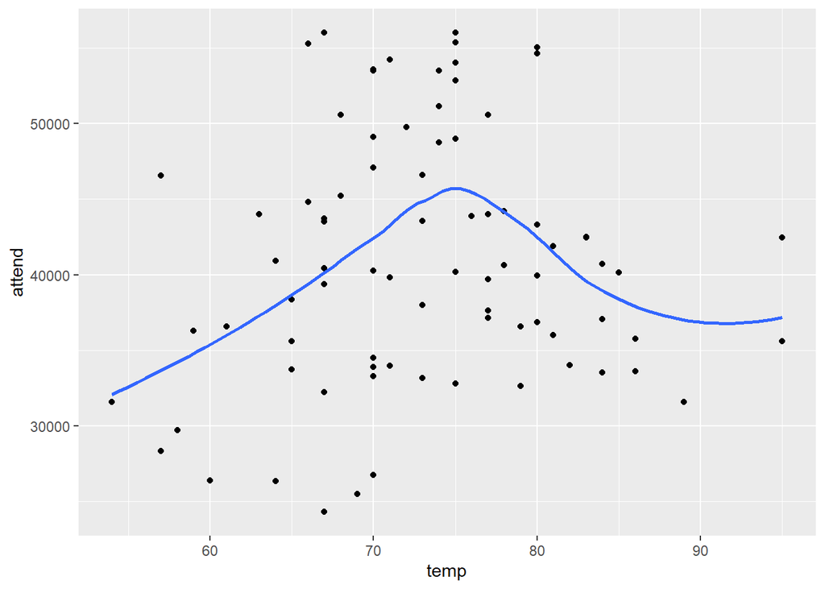

   The smoother makes clear that uncomfortably low and high temperatures discourage fans from attending game in the stadium.

   ```r
   d2 %>%
     ggplot(aes(temp, attend)) +
     geom_point() +
     geom_smooth(se=FALSE, method="loess")
   ```

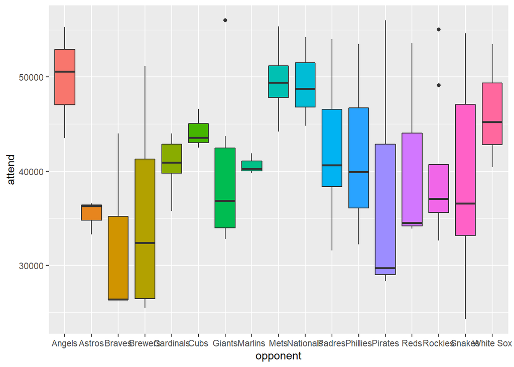

   ```r
   d2 %>%
     ggplot(aes(opponent, attend)) +
     geom_boxplot(aes(fill=opponent)) +
     theme(legend.position = "none")
   ```

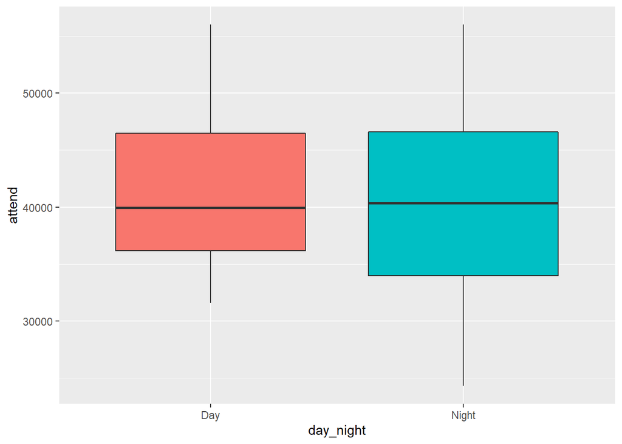

   ```r
   d2 %>%
     ggplot(aes(day_night, attend)) +
     geom_boxplot(aes(fill=day_night)) +
     theme(legend.position = "none")
   ```

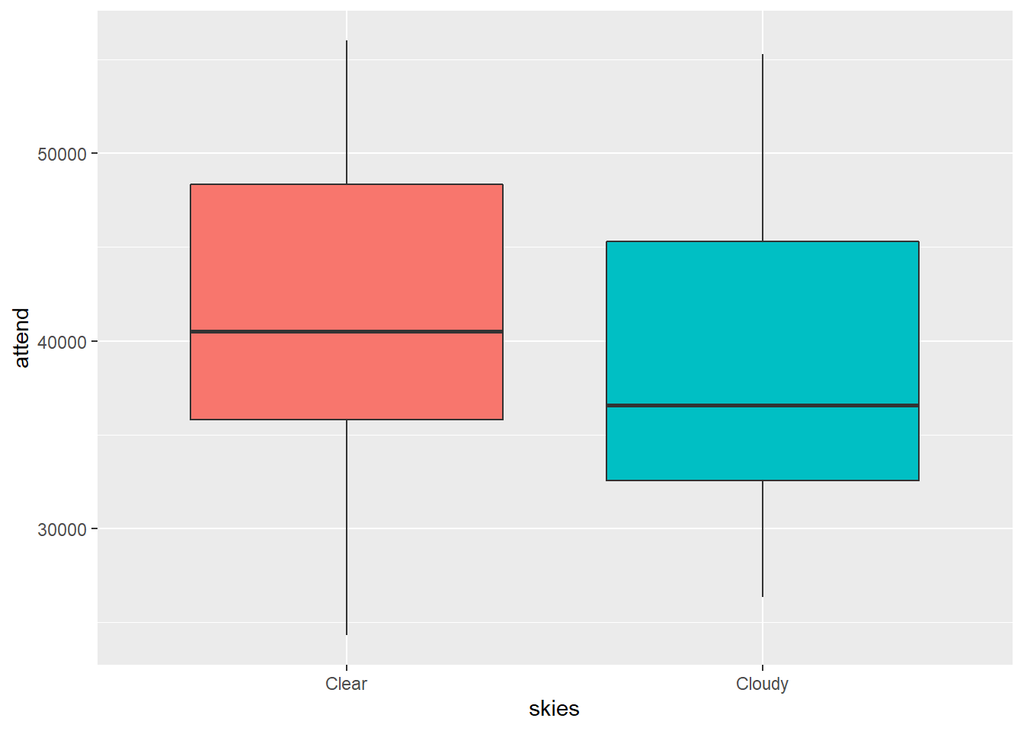

   ```r
   d2 %>%
     ggplot(aes(skies, attend)) +
     geom_boxplot(aes(fill=skies)) +
     theme(legend.position = "none")
   ```

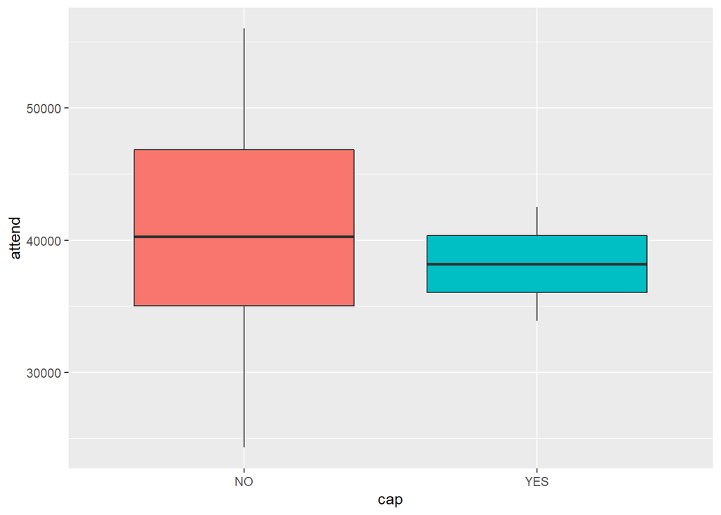

   ```r
   d2 %>%
   ggplot(aes(cap, attend)) +
   geom_boxplot(aes(fill=cap)) +
   theme(legend.position = "none")
   ```

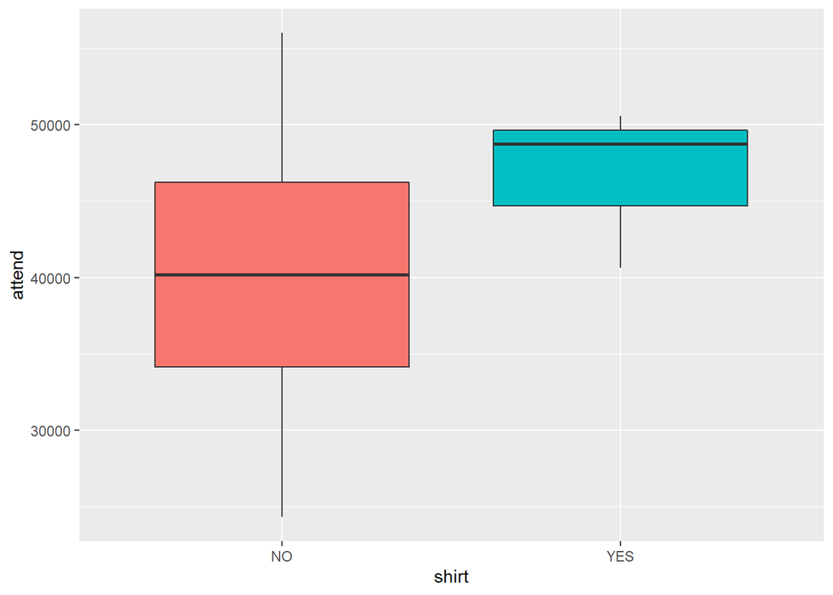

   ```r
     d2 %>%
   ggplot(aes(shirt, attend)) +
   geom_boxplot(aes(fill=shirt)) +
   theme(legend.position = "none")
   ```

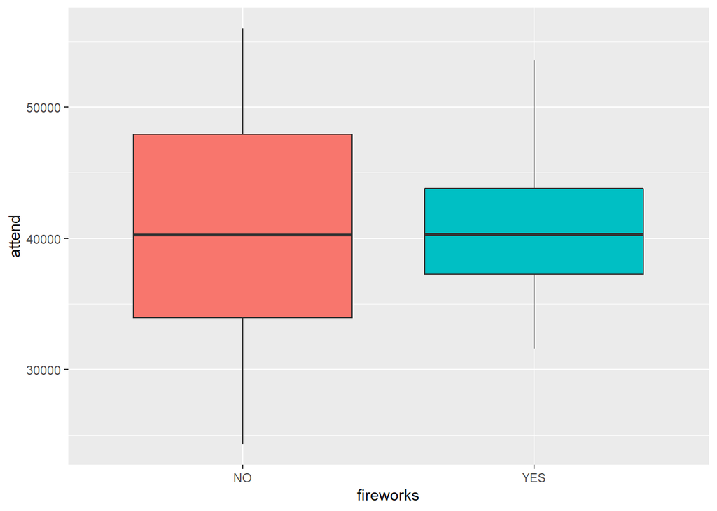

   ```r
     d2 %>%
   ggplot(aes(fireworks, attend)) +
   geom_boxplot(aes(fill=fireworks)) +
   theme(legend.position = "none")
   ```

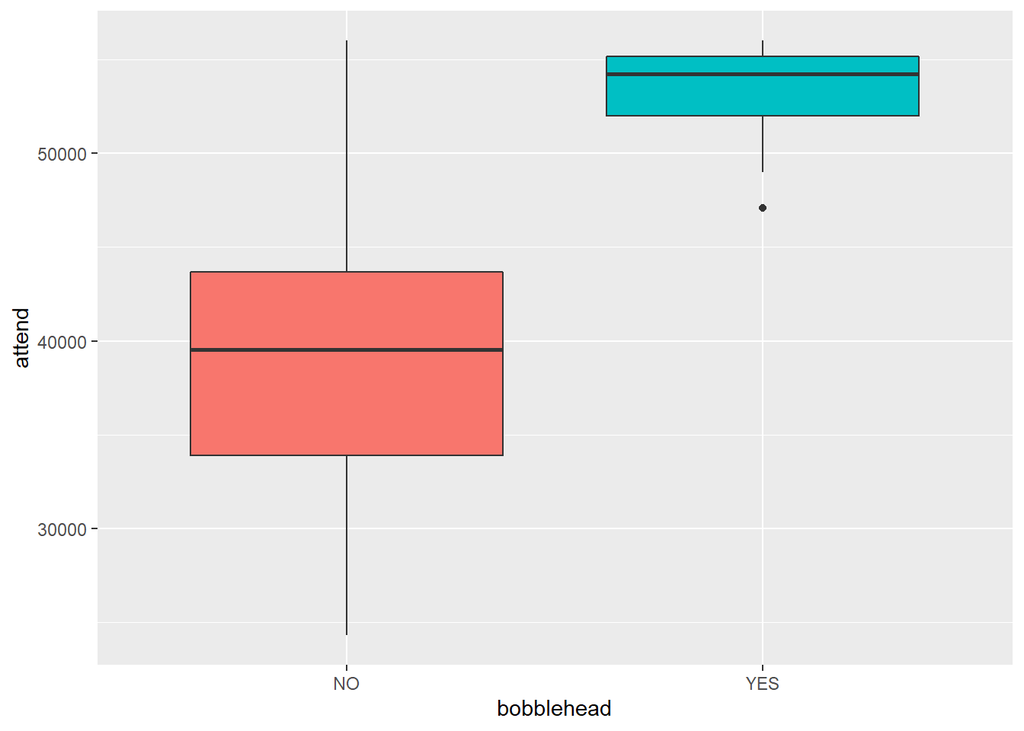

   ```r
     d2 %>%
   ggplot(aes(bobblehead, attend)) +
   geom_boxplot(aes(fill=bobblehead)) +
   theme(legend.position = "none")
   ```

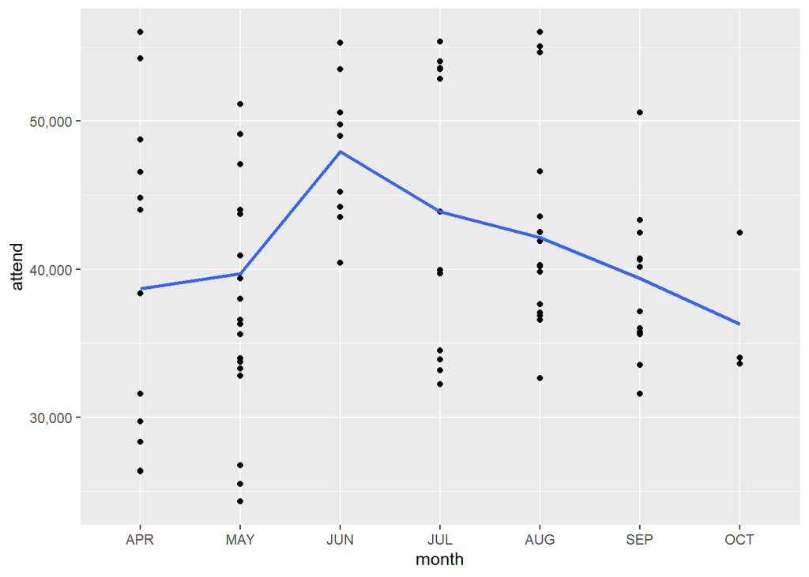

   ```r
     d2 %>%
   ggplot(aes(month, attend, group=1)) +
   geom_point() +
   scale_y_continuous(labels=scales::comma) +
   geom_smooth(se=FALSE, method="loess")
   ```

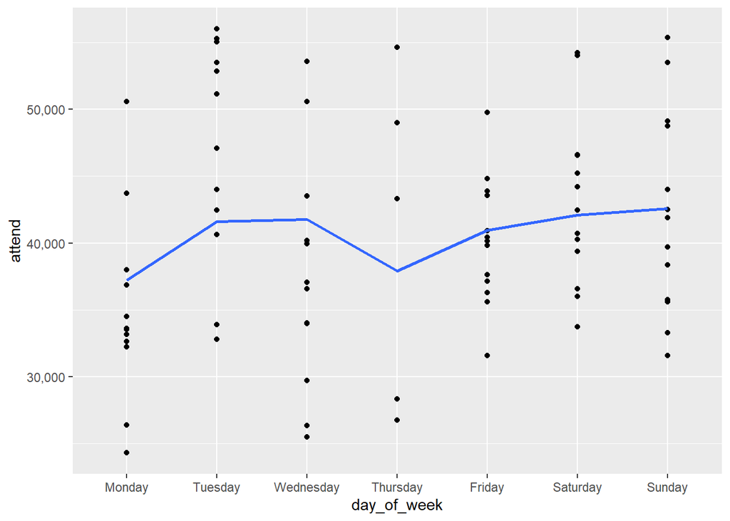

   ```r
     d2 %>%
   ggplot(aes(day_of_week, attend, group=1)) +
   geom_point() +
   scale_y_continuous(labels=scales::comma) +
   geom_smooth(se=FALSE, method="loess")
   ```

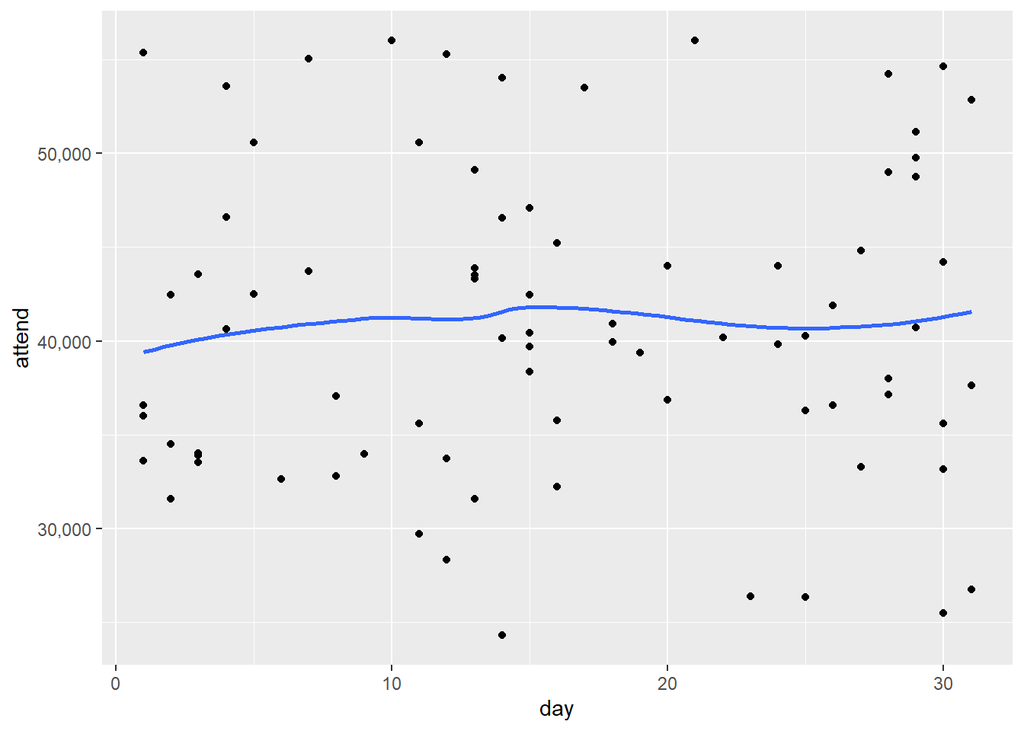

   ```r
     d2 %>%
   ggplot(aes(day, attend, group=1)) +
   geom_point() +
   scale_y_continuous(labels=scales::comma) +
   geom_smooth(se=FALSE, method="loess")
   ```

# A linear regression model

Regress attendance on month, day of the week, and bobblehead promotion.

$$\text{attendance}_i = \beta_0 + \beta_{MAY} \delta_{MA, i} + \ldots + \beta_{OCT} \delta_{OCT, i} + \beta_{Tue}\delta_{Tue, i} + \ldots + \beta_{Sun}\delta_{Sun, i} + \beta_{YES} \delta_{YES, i} + \varepsilon_i.$$
for $i =1,\ldots, 81,$ where $\varepsilon_i \sim \text{Normal}(0, \sigma^2)$, and the $\delta$ are dummy variables, one if the associated event occurs for the $i$th game, and zero otherwise.
$$\begin{aligned}
\beta_0 &:\text{average attendance for a typical game played on some Monday in APR when no bobblehead was NOT given away,}\\
\beta_{MAY}&: \text{average difference in attendance for a typical game played in MAY rather than APR,}\\
\beta_{Tue}&: \text{average difference in attendance for a typical game played on Tuesday rather than Monday,}\\
\beta_{YES}&: \text{average difference in attendance for a typical game when a bobblehead is given away.}
\end{aligned}$$
and other betas are defined similarly.

We find the $\beta$ with maximum likelihood:

```r
lmod <- lm(attend ~ month + day_of_week + bobblehead, d2)
lmod
```

```
Call:
lm(formula = attend ~ month + day_of_week + bobblehead, data = d2)

Coefficients:
         (Intercept)              monthMAY              monthJUN
            33909.16              -2385.62               7163.23
            monthJUL              monthAUG              monthSEP
             2849.83               2377.92                 29.03
            monthOCT    day_of_weekTuesday  day_of_weekWednesday
             -662.67               7911.49               2460.02
 day_of_weekThursday     day_of_weekFriday   day_of_weekSaturday
              775.36               4883.82               6372.06
   day_of_weekSunday         bobbleheadYES
             6724.00              10714.90
```

```r
summary(lmod)
```

```
Call:
lm(formula = attend ~ month + day_of_week + bobblehead, data = d2)

Residuals:
     Min       1Q   Median       3Q      Max
-10786.5  -3628.1   -516.1   2230.2  14351.0

Coefficients:
                     Estimate Std. Error t value             Pr(>|t|)
(Intercept)          33909.16    2521.81  13.446 < 0.0000000000000002 ***
monthMAY             -2385.62    2291.22  -1.041              0.30152
monthJUN              7163.23    2732.72   2.621              0.01083 *
monthJUL              2849.83    2578.60   1.105              0.27303
monthAUG              2377.92    2402.91   0.990              0.32593
monthSEP                29.03    2521.25   0.012              0.99085
monthOCT              -662.67    4046.45  -0.164              0.87041
day_of_weekTuesday    7911.49    2702.21   2.928              0.00466 **
day_of_weekWednesday  2460.02    2514.03   0.979              0.33134
day_of_weekThursday    775.36    3486.15   0.222              0.82467
day_of_weekFriday     4883.82    2504.65   1.950              0.05537 .
day_of_weekSaturday   6372.06    2552.08   2.497              0.01500 *
day_of_weekSunday     6724.00    2506.72   2.682              0.00920 **
bobbleheadYES        10714.90    2419.52   4.429            0.0000359 ***
---
Signif. codes:  0 '***' 0.001 '**' 0.01 '*' 0.05 '.' 0.1 ' ' 1

Residual standard error: 6120 on 67 degrees of freedom
Multiple R-squared:  0.5444,    Adjusted R-squared:  0.456
F-statistic: 6.158 on 13 and 67 DF,  p-value: 0.0000002083
```

```r
# lmod %>% pander(caption = "Linear regression model")
```

- We expect 33,909 attendance on a game played on some Monday in APR and no bobblehead was given.
- If, instead, game is played on MAY, the attendance is expected to drop by 2,386.
- If a bobblehead is given away, then we expect attendance to increase by 10,715.

The bobblehead seems to increase the attendance number by a larger quantity than any other factor. However, is the difference statistically significant? We will test it below.

2. Is there any evidence for a relationship between attendance and other variables? Why or why not?

```r
small <- update(lmod, . ~ 1 )
anova(small, lmod)
```

```
Analysis of Variance Table

Model 1: attend ~ 1
Model 2: attend ~ month + day_of_week + bobblehead
  Res.Df        RSS Df  Sum of Sq      F       Pr(>F)
1     80 5507932888
2     67 2509574563 13 2998358324 6.1576 0.0000002083 ***
---
Signif. codes:  0 '***' 0.001 '**' 0.01 '*' 0.05 '.' 0.1 ' ' 1
```

Test $H_0: \beta_{MAY} = \ldots = \beta_{OCT} = \beta_{Tue} = \ldots = \beta_{Sun} = \beta_{YES} = 0$

We reject small/null model because F stat is large (or p-value is small <= 0.05). We conclude that at least one of variables on thr right has some reltion to attendance.

3. Does the bobblehead promotion have a statistically significant effect on the attendance?

Test $H_0: \beta_{YES} = 0$.

```r
small <-  update(lmod, . ~ . - bobblehead)
anova(small, lmod)
```

```
Analysis of Variance Table

Model 1: attend ~ month + day_of_week
Model 2: attend ~ month + day_of_week + bobblehead
  Res.Df        RSS Df Sum of Sq      F    Pr(>F)
1     68 3244161740
2     67 2509574563  1 734587177 19.612 0.0000359 ***
---
Signif. codes:  0 '***' 0.001 '**' 0.01 '*' 0.05 '.' 0.1 ' ' 1
```

```
Since p-value is practically zero, we reject the small model, which means that bobblehead is important in explaing the increase in attendance.
```

4. Do month and day of week variables help to explain the number of attendants?

Similarly, we will conduct F tests.

```r
drop1(lmod, test="F")
```

```
Single term deletions

Model:
attend ~ month + day_of_week + bobblehead
            Df Sum of Sq        RSS    AIC F value    Pr(>F)
<none>                   2509574563 1425.2
month        6 620147363 3129721926 1431.0  2.7594   0.01858 *
day_of_week  6 575839199 3085413762 1429.9  2.5623   0.02704 *
bobblehead   1 734587177 3244161740 1444.0 19.6118 0.0000359 ***
---
Signif. codes:  0 '***' 0.001 '**' 0.01 '*' 0.05 '.' 0.1 ' ' 1
```

All explanatory variables are needed in the model to get a good accuracy on future predictions (AIC) and to explain variation in the existing attendance data (F-test). So we stick to full model.

$$AIC = -2 \times \text{log-likelihood} + 2\times\text{number of parameters in the model}$$

5. How many fans are expected to be drawn **alone by a bobblehead promotion** to a home game? Give a 90% confidence interval.

The expected additional number of attendance is $\beta_{YES}$, which is estimated as 10,715.

```r
confint(lmod, level = 0.90)["bobbleheadYES",]
```

```
      5 %      95 %
 6679.347 14750.460
```

6. How good does the model fit to the data? Why? Comment on residual standard error and R$^2$. Plot observed attendance against predicted attendance.

R^2 is the fraction of variation in attendance (in the past 81 games) explained by the current (month, day_of_week, bobblehead). Here, R^2 becomes 54% of variation explained. Our model is not too bad, but not too good either.

The standard deviation of error is 6,120, which is 15% of average attendance we expect. Compared to 40% typical error percentage, this is not bad.

7. Predict the number of attendees to a typical home game on a **Wednesday** in **June** if a **bobblehead promotion** is extended. Give a 90% prediction interval.

```r
d2$month %>% levels()
```

```
[1] "APR" "MAY" "JUN" "JUL" "AUG" "SEP" "OCT"
```

```r
d2$day_of_week %>%  levels()
```

```
[1] "Monday"    "Tuesday"   "Wednesday" "Thursday"  "Friday"    "Saturday"
[7] "Sunday"
```

```r
d2$bobblehead %>%  unique()
```

```
[1] "NO"  "YES"
```

```r
newdata <- data.frame(month = "JUN", day_of_week = "Wednesday",
                      bobblehead = "YES")
predict(lmod, newdata=newdata, level=0.90,
        interval = "prediction")
```

```
       fit     lwr      upr
1 54247.32 42491.1 66003.55
```

```r
# ?predict.lm
```

# More ideas about improving our model

## Introduce new variables.

Let us check if `opponent` variable should be added to the model.

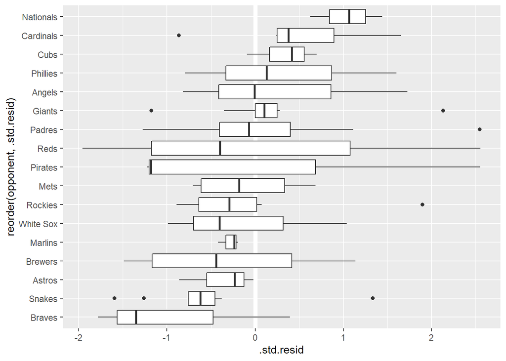

```r
broom::augment(lmod, data=d2) %>%
  mutate(opponent = factor(opponent)) %>%
  ggplot(aes(reorder(opponent, .std.resid), .std.resid)) +
  geom_hline(yintercept=0, col="white", size=2) +
  geom_boxplot() +
  coord_flip()
```

Because we are consistently under- and over-estimating attendance in games played against certain opponents, it is a good idea to add. opponent.

## Introduce interaction between existing variables

It is natural to expect interaction between month and day_of_week: during summer months, people are expected to spend more time outdoors, especially, during weekends. Let us see if data are consistent with current no-interaction model estimates.

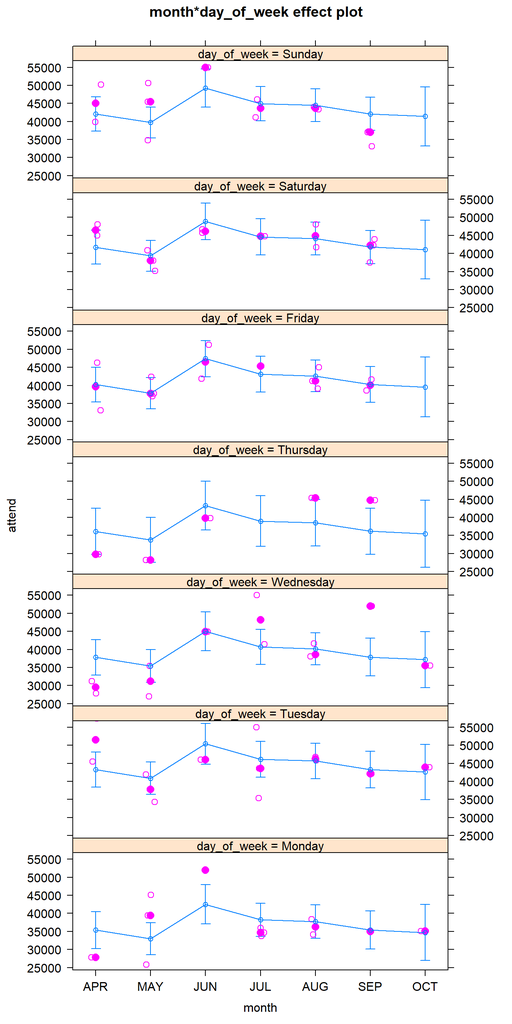

```r
d3 <- mutate(d2, bobblehead = factor(bobblehead))
lmod <- update(lmod, data  = d3)

effects::effect(c("month","day_of_week"), lmod,
                partial.residuals = TRUE ) %>% plot(layout = c(1,7))
```

Model seems to overestimate effects of Wednesday and Thursday in APR and MAY and underestimate Tursday effects in AUG and SEP. Let us augment model with interaction term and run an F-test to check if it is statistically significant.

### Model selection with F-test

```r
lmod
```

```
Call:
lm(formula = attend ~ month + day_of_week + bobblehead, data = d3)

Coefficients:
         (Intercept)              monthMAY              monthJUN
            33909.16              -2385.62               7163.23
            monthJUL              monthAUG              monthSEP
             2849.83               2377.92                 29.03
            monthOCT    day_of_weekTuesday  day_of_weekWednesday
             -662.67               7911.49               2460.02
 day_of_weekThursday     day_of_weekFriday   day_of_weekSaturday
              775.36               4883.82               6372.06
   day_of_weekSunday         bobbleheadYES
             6724.00              10714.90
```

```r
large <- update(lmod, . ~ . + month:day_of_week)
anova(lmod, large)
```

```
Analysis of Variance Table

Model 1: attend ~ month + day_of_week + bobblehead
Model 2: attend ~ month + day_of_week + bobblehead + month:day_of_week
  Res.Df        RSS Df  Sum of Sq    F Pr(>F)
1     67 2509574563
2     36 1082895916 31 1426678647 1.53 0.1096
```

P-value is large, so we cannot reject small model. Therefore, F-test concluded that interaction between month and day_of_week is unimportant.

### Model selection with AIC

```r
 final <- update(lmod, . ~ .^2) %>%  step()
```

```
Start:  AIC=1422.53
attend ~ month + day_of_week + bobblehead + month:day_of_week +
    month:bobblehead + day_of_week:bobblehead

                         Df  Sum of Sq        RSS    AIC
- day_of_week:bobblehead  1   12082574 1061414706 1421.5
- month:bobblehead        1   17121963 1066454095 1421.8
<none>                                 1049332132 1422.5
- month:day_of_week      27 1335988226 2385320358 1435.0

Step:  AIC=1421.46
attend ~ month + day_of_week + bobblehead + month:day_of_week +
    month:bobblehead

                    Df  Sum of Sq        RSS    AIC
- month:bobblehead   2   21481210 1082895916 1419.1
<none>                            1061414706 1421.5
- month:day_of_week 29 1363309764 2424724470 1430.4

Step:  AIC=1419.08
attend ~ month + day_of_week + bobblehead + month:day_of_week

                    Df  Sum of Sq        RSS    AIC
<none>                            1082895916 1419.1
- month:day_of_week 31 1426678647 2509574563 1425.2
- bobblehead         1  351400539 1434296455 1439.8
```

Step() applies repeatedly drop1 to find the model with the least AIC until no new term is found to drop out of last model. So interaction terms other than month:day_of_week turn out be unimportant from prediction accuracy on unseen data as estimated by AIC.

### Model selection with cross-validation and t-test

Check if the interaction term is necessary with **cross-validation**

```r
set.seed(460)

nfolds <- 5
folds <- rep(seq(5), nrow(d2), len=nrow(d2)) %>% sample()
rmse_lmod <- rep(NA, nfolds)
rmse_lmod_interaction <- rep(NA, nfolds)

lmod_interaction <- update(lmod, . ~ . + month:day_of_week)

for (i in seq(nfolds)){
  train <- d2[folds!=i,]
  test <- d2[folds==i,]

  # train lm without interaction model
  lmod_train <- update(lmod, data = train)
  lmod_test <- predict(lmod_train, newdata = test)
  rmse_lmod[i] <- (test$attend - lmod_test)^2 %>% mean() %>% sqrt()

  # train lm with interaction model
  lmod_interaction_train <- update(lmod_interaction, data = train)
  lmod_interaction_test <- suppressWarnings(predict(lmod_interaction_train, newdata = test))
  rmse_lmod_interaction[i] <- (test$attend - lmod_interaction_test)^2 %>% mean() %>% sqrt()
}

cv <- tibble(lmod = rmse_lmod, lmod_interaction = rmse_lmod_interaction) %>%
  mutate(dif_rmse = lmod - lmod_interaction)

cv %>%
  apply(2,mean)
```

```
            lmod lmod_interaction         dif_rmse
        6380.985         9945.353        -3564.368
```

Run a **two-sided t-test** on the difference of rmse values to check if the mean rmse values for models with and without interaction terms are the same.

```r
t.test(x = cv$dif_rmse)
```

```
    One Sample t-test

data:  cv$dif_rmse
t = -3.3067, df = 4, p-value = 0.02975
alternative hypothesis: true mean is not equal to 0
95 percent confidence interval:
 -6557.1885  -571.5477
sample estimates:
mean of x
-3564.368
```

Because p-value is small, we conclude that the models have different mean rmse values. Because the t statistic is negative, model without interaction term seems to have a lower rmse than the model with interaction term.

# Next: Nonlinear and nonparametric regression: recursive partitioning and random forests

Thursday lecture was cancelled as part of Covid 19 counter-measures.

# Project (will be graded)

Include **all variables** and conduct a full regression analysis of the problem. Submit your `R markdown` and `html` files to course homepage on moodle in a **single** zip file. **Zip file must be named as “StuID”.zip; for example, 21601224.zip** Below are the recap of the major steps to guide you through your project:

1. Explore the relation between attendance and explanatory variables with scatter, bar, box plots
2. Use Chi-squared test to check if there is attendance and explanatory variables are mutually independent.
3. Fit regression model with all explanatory variables.
   1. How good does your model fit to data?
   2. Which variables are significant? Use F-test, AIC, and cross-validation.
   3. Is bobblehead still significant? What is expected additional attendance due bobblehead? What is 80% confidence interval?
   4. Check model diagnostics.
      1. Does any quantitative explanatory variable need a nonlinear transformation?
      2. Does your model benefit from adding two-way interaction terms between any two explanatory variables? Use cross-validation to support your decision.

# Bibliography

Project Answers:

[output not shown]

```r
options(scipen=100)
skies_tbl <- d2 %>%
      mutate(attend_cut = cut(attend, breaks = c(0, quantile(attend, prob=(1:2)/3), Inf))) %>%
      xtabs(~ attend_cut + skies, .)

skies_tbl
```

```
##                      skies
## attend_cut            Clear Cloudy
##   (0,3.66e+04]           17     10
##   (3.66e+04,4.39e+04]    24      3
##   (4.39e+04,Inf]         21      6
```

```r
chisq.test(skies_tbl) %>%   pander()
```

Pearson’s Chi-squared test: `skies_tbl`

| Test statistic | df | P value |
| --- | --- | --- |
| 5.088 | 2 | 0.07854 |

Chi-square test has a marginal 7% p-value, under which we cannot reject independence of attendance and skies, but its small value calls for a more comprehensive analysis together with other values.

```r
#cap Chi-square
cap_tbl <- d2 %>%
      mutate(attend_cut = cut(attend, breaks = c(0, quantile(attend, prob=(1:2)/3), Inf))) %>%
      xtabs(~ attend_cut + cap, .)

cap_tbl
```

```
##                      cap
## attend_cut            NO YES
##   (0,3.66e+04]        26   1
##   (3.66e+04,4.39e+04] 26   1
##   (4.39e+04,Inf]      27   0
```

```r
chisq.test(cap_tbl) %>%   pander()
```

Pearson’s Chi-squared test: `cap_tbl`

| Test statistic | df | P value |
| --- | --- | --- |
| 1.025 | 2 | 0.5989 |

As the p value (0.5989) of this chi-squared test is much higher than our significance level(0.05), we cannot reject the independence between the attendance variable and cap variable. However, as we can see on the graph, only two times the cap was distributed during the games. Hence, obviously this data is insufficient for us to decide on the independence situation.

```r
#shirt chi-square
shirt_tbl <- d2 %>%
      mutate(attend_cut = cut(attend, breaks = c(0, quantile(attend, prob=(1:2)/3), Inf))) %>%
      xtabs(~ attend_cut + shirt, .)

shirt_tbl
```

```
##                      shirt
## attend_cut            NO YES
##   (0,3.66e+04]        27   0
##   (3.66e+04,4.39e+04] 26   1
##   (4.39e+04,Inf]      25   2
```

```r
chisq.test(shirt_tbl) %>%   pander()
```

Pearson’s Chi-squared test: `shirt_tbl`

| Test statistic | df | P value |
| --- | --- | --- |
| 2.077 | 2 | 0.354 |

As the p value (0.354) of this chi-squared test is much higher than our significance level(0.05), we cannot reject the independence between the attendance and shirt distribution. However, as we can see on the graph, only 3 times the shirt was distributed during the games. Hence, obviously this data is insufficient for us to decide on the independence situation.

```r
#fireworks chi-squared
firework_tbl <- d2 %>%
      mutate(attend_cut = cut(attend, breaks = c(0, quantile(attend, prob=(1:2)/3), Inf))) %>%
      xtabs(~ attend_cut + fireworks, .)

firework_tbl
```

```
##                      fireworks
## attend_cut            NO YES
##   (0,3.66e+04]        24   3
##   (3.66e+04,4.39e+04] 19   8
##   (4.39e+04,Inf]      24   3
```

```r
chisq.test(firework_tbl) %>%   pander()
```

Pearson’s Chi-squared test: `firework_tbl`

| Test statistic | df | P value |
| --- | --- | --- |
| 4.318 | 2 | 0.1155 |

```r
#bobblehead chi-squared
bobb_tbl <- d2 %>%
      mutate(attend_cut = cut(attend, breaks = c(0, quantile(attend, prob=(1:2)/3), Inf))) %>%
      xtabs(~ attend_cut + bobblehead, .)

bobb_tbl
```

```
##                      bobblehead
## attend_cut            NO YES
##   (0,3.66e+04]        27   0
##   (3.66e+04,4.39e+04] 27   0
##   (4.39e+04,Inf]      16  11
```

```r
chisq.test(bobb_tbl) %>%   pander()
```

Pearson’s Chi-squared test: `bobb_tbl`

| Test statistic | df | P value |
| --- | --- | --- |
| 25.46 | 2 | 0.000002965 * * * |

As the p value is much smaller than our significance level (0.05), we reject the the independence between attendence and bobblehead. We definitely see that bobblehead is a strong candidate for our regression model.

```r
#month chi-squared
month_tbl <- d2 %>%
      mutate(attend_cut = cut(attend, breaks = c(0, quantile(attend, prob=(1:2)/3), Inf))) %>%
      xtabs(~ attend_cut + month, .)

month_tbl
```

```
##                      month
## attend_cut            APR MAY JUN JUL AUG SEP OCT
##   (0,3.66e+04]          5  10   0   4   1   5   2
##   (3.66e+04,4.39e+04]   1   4   2   3  10   6   1
##   (4.39e+04,Inf]        6   4   7   5   4   1   0
```

```r
chisq.test(month_tbl) %>%   pander()
```

Pearson’s Chi-squared test: `month_tbl`

| Test statistic | df | P value |
| --- | --- | --- |
| 30.57 | 12 | 0.002293 * * |

As the p value of this chi-squared test is much smaller than our significance level (0.05), we reject the independence between attendence and month. We consider month variable as a strong candidate for our regression model as well.

```r
dow_table <- d2 %>%
  mutate(attend_cut = cut(attend, breaks = c(0, quantile(attend, prob=(1:2)/3), Inf))) %>%
  xtabs(~ attend_cut + day_of_week, .)

chisq.test(dow_table)
```

```
##
##  Pearson's Chi-squared test
##
## data:  dow_table
## X-squared = 21.938, df = 12, p-value = 0.03822
```

As the p-value (0.03822) is smaller than our significance level (0.05), we reject the independence between attendence and day_of_week. We can consider the factor of day_of_week is a candidate for our regression model.

```r
#opponent chi-squared
opponent_tbl <- d2 %>%
      mutate(attend_cut = cut(attend, breaks = c(0, quantile(attend, prob=(1:2)/3), Inf))) %>%
      xtabs(~ attend_cut + opponent, .)
opponent_tbl
```

```
##                      opponent
## attend_cut            Angels Astros Braves Brewers Cardinals Cubs Giants
##   (0,3.66e+04]             0      3      2       2         1    0      4
##   (3.66e+04,4.39e+04]      1      0      0       1         5    2      4
##   (4.39e+04,Inf]           2      0      1       1         1    1      1
##                      opponent
## attend_cut            Marlins Mets Nationals Padres Phillies Pirates Reds
##   (0,3.66e+04]              0    0         0      2        1       2    2
##   (3.66e+04,4.39e+04]       3    0         0      4        1       0    0
##   (4.39e+04,Inf]            0    4         3      3        1       1    1
##                      opponent
## attend_cut            Rockies Snakes White Sox
##   (0,3.66e+04]              4      4         0
##   (3.66e+04,4.39e+04]       3      2         1
##   (4.39e+04,Inf]            2      3         2
```

```r
chisq.test(opponent_tbl) %>%   pander()
```

Pearson’s Chi-squared test: `opponent_tbl`

| Test statistic | df | P value |
| --- | --- | --- |
| 47.07 | 32 | 0.04178 * |

The p-value (0.04178) is smaller than our significance level (0.05), we reject the independence between attendence level and the opponent. We can consider the opponent variable is a candidate for our regression model.

```r
#day_night chi-squared
daynight_tbl <- d2 %>%
      mutate(attend_cut = cut(attend, breaks = c(0, quantile(attend, prob=(1:2)/3), Inf))) %>%
      xtabs(~ attend_cut + day_night, .)

daynight_tbl
```

```
##                      day_night
## attend_cut            Day Night
##   (0,3.66e+04]          4    23
##   (3.66e+04,4.39e+04]   6    21
##   (4.39e+04,Inf]        5    22
```

```r
chisq.test(daynight_tbl) %>%   pander()
```

Pearson’s Chi-squared test: `daynight_tbl`

| Test statistic | df | P value |
| --- | --- | --- |
| 0.4909 | 2 | 0.7823 |

```r
#temperature chi-squared

temp_tbl <- d2 %>%
  mutate(attend_cut = cut(attend, breaks = c(0, quantile(attend, prob=(1:2)/3), Inf)),
  temp_cut = cut(temp, breaks = c(0, quantile(temp, prob=(1:4)/5), Inf))) %>%
  xtabs(~ attend_cut + temp_cut, .)

temp_tbl
```

```
##                      temp_cut
## attend_cut            (0,67] (67,70] (70,75] (75,80] (80,Inf]
##   (0,3.66e+04]            11       5       3       1        7
##   (3.66e+04,4.39e+04]      6       1       4       9        7
##   (4.39e+04,Inf]           5       6      11       5        0
```

```r
chisq.test(temp_tbl)
```

```
##
##  Pearson's Chi-squared test
##
## data:  temp_tbl
## X-squared = 26.052, df = 8, p-value = 0.001029
```

As the p value of this chi-squared test (0.001029) is much smaller than our significance level (0.05), we reject the independence between attendence and temperature. We consider temperature variable as a strong candidate for our regression model as well.

```r
#temperature chi-squared
day_tbl <- d2 %>%
      mutate(attend_cut = cut(attend, breaks = c(0, quantile(attend, prob=(1:2)/3), Inf))) %>%
      xtabs(~ attend_cut + day, .)

day_tbl
```

```
##                      day
## attend_cut            1 2 3 4 5 6 7 8 9 10 11 12 13 14 15 16 17 18 19 20
##   (0,3.66e+04]        2 2 3 0 0 1 0 1 1  0  2  2  1  1  0  2  0  0  0  0
##   (3.66e+04,4.39e+04] 1 1 1 1 1 0 1 1 0  0  0  0  3  1  4  0  0  2  1  1
##   (4.39e+04,Inf]      1 0 0 2 1 0 1 0 0  1  1  1  1  2  1  1  2  0  0  1
##                      day
## attend_cut            21 22 23 24 25 26 27 28 29 30 31
##   (0,3.66e+04]         0  0  1  0  2  1  1  0  0  3  1
##   (3.66e+04,4.39e+04]  0  1  0  1  1  1  0  2  1  0  1
##   (4.39e+04,Inf]       1  0  0  1  0  0  1  2  3  2  1
```

```r
chisq.test(day_tbl) %>%   pander()
```

Pearson’s Chi-squared test: `day_tbl`

| Test statistic | df | P value |
| --- | --- | --- |
| 60.6 | 60 | 0.454 |

As we logically considered the day of month is a insignificant predictor variable for our regression model, we still needed to see mathematically that we cannot reject the independence between the day of month and attendance. Hence, as the p-value is much higher than our significance level, this result validates our assumption.

In class we have had some tests already to see if the opponent variable is a good candidate for our regression model:

```r
lmod_opponent <- update(lmod,.~. + opponent)
small <-  update(lmod_opponent, . ~ . - opponent)
anova(small, lmod_opponent)
```

```
Analysis of Variance Table

Model 1: attend ~ month + day_of_week + bobblehead
Model 2: attend ~ month + day_of_week + bobblehead + opponent
  Res.Df        RSS Df Sum of Sq      F Pr(>F)
1     67 2509574563
2     51 2017425853 16 492148710 0.7776 0.7022
```

Since p-value is too big, we cannot reject the small model, which means that opponent may no be as important in explaing the increase in attendance.

Let’s check if `opponent` variable should be added to the model.

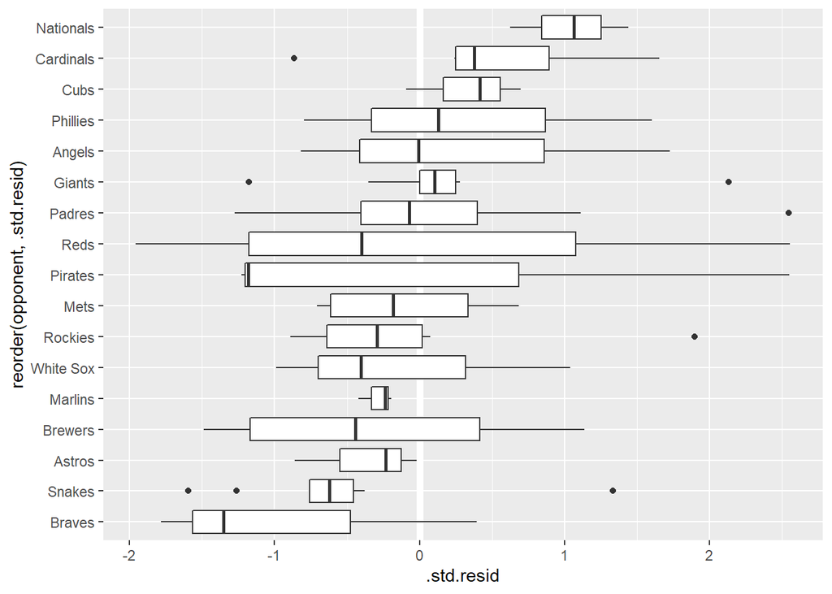

```r
broom::augment(lmod, data=d2) %>%
  mutate(opponent = factor(opponent)) %>%
  ggplot(aes(reorder(opponent, .std.resid), .std.resid)) +
  geom_hline(yintercept=0, col="white", size=2) +
  geom_boxplot() +
  coord_flip()
```

Because we are consistently under- and over-estimating attendance in games played against certain opponents, it is a good idea to add. opponent.

We have investigated if adding opponent is a good idea and mathematical results showed us that it is not. However, intrinsinctly we are considered with the effect of the interaction between variables bobblehead and opponent. the main reason for us to investigate and test it is to see if the attendants are interested in the bobble heads of a player playing in a famous opponent team.

#Let’s look if bobblehead, together with opponent can influence the increase in number of attendants as an intercept:

### Model selection with F-test

```r
lmod
```

```
Call:
lm(formula = attend ~ month + day_of_week + bobblehead, data = d3)

Coefficients:
         (Intercept)              monthMAY              monthJUN
            33909.16              -2385.62               7163.23
            monthJUL              monthAUG              monthSEP
             2849.83               2377.92                 29.03
            monthOCT    day_of_weekTuesday  day_of_weekWednesday
             -662.67               7911.49               2460.02
 day_of_weekThursday     day_of_weekFriday   day_of_weekSaturday
              775.36               4883.82               6372.06
   day_of_weekSunday         bobbleheadYES
             6724.00              10714.90
```

```r
large <- update(lmod, . ~ . + bobblehead:opponent)
anova(lmod, large)
```

```
Analysis of Variance Table

Model 1: attend ~ month + day_of_week + bobblehead
Model 2: attend ~ month + day_of_week + bobblehead + bobblehead:opponent
  Res.Df        RSS Df Sum of Sq      F Pr(>F)
1     67 2509574563
2     44 1881477777 23 628096786 0.6386 0.8754
```

The p-value is too much higher than our significance level, thus we conclude that we cannot reject the independence between increase in number of attendants and the intercept of bobblehead and opponent. We conclude that the intercept of those two variables are insignificant for our regression model.

```r
lmod <- lm(attend ~ month + day_of_week + bobblehead , d2)
lmod
```

```
Call:
lm(formula = attend ~ month + day_of_week + bobblehead, data = d2)

Coefficients:
         (Intercept)              monthMAY              monthJUN
            33909.16              -2385.62               7163.23
            monthJUL              monthAUG              monthSEP
             2849.83               2377.92                 29.03
            monthOCT    day_of_weekTuesday  day_of_weekWednesday
             -662.67               7911.49               2460.02
 day_of_weekThursday     day_of_weekFriday   day_of_weekSaturday
              775.36               4883.82               6372.06
   day_of_weekSunday         bobbleheadYES
             6724.00              10714.90
```

```r
summary(lmod)
```

```
Call:
lm(formula = attend ~ month + day_of_week + bobblehead, data = d2)

Residuals:
     Min       1Q   Median       3Q      Max
-10786.5  -3628.1   -516.1   2230.2  14351.0

Coefficients:
                     Estimate Std. Error t value             Pr(>|t|)
(Intercept)          33909.16    2521.81  13.446 < 0.0000000000000002 ***
monthMAY             -2385.62    2291.22  -1.041              0.30152
monthJUN              7163.23    2732.72   2.621              0.01083 *
monthJUL              2849.83    2578.60   1.105              0.27303
monthAUG              2377.92    2402.91   0.990              0.32593
monthSEP                29.03    2521.25   0.012              0.99085
monthOCT              -662.67    4046.45  -0.164              0.87041
day_of_weekTuesday    7911.49    2702.21   2.928              0.00466 **
day_of_weekWednesday  2460.02    2514.03   0.979              0.33134
day_of_weekThursday    775.36    3486.15   0.222              0.82467
day_of_weekFriday     4883.82    2504.65   1.950              0.05537 .
day_of_weekSaturday   6372.06    2552.08   2.497              0.01500 *
day_of_weekSunday     6724.00    2506.72   2.682              0.00920 **
bobbleheadYES        10714.90    2419.52   4.429            0.0000359 ***
---
Signif. codes:  0 '***' 0.001 '**' 0.01 '*' 0.05 '.' 0.1 ' ' 1

Residual standard error: 6120 on 67 degrees of freedom
Multiple R-squared:  0.5444,    Adjusted R-squared:  0.456
F-statistic: 6.158 on 13 and 67 DF,  p-value: 0.0000002083
```

```r
# lmod %>% pander(caption = "Linear regression model")
```

Let us observe and try to include more variables which we consider may be strong candidates for our model via the previous chi squared tests.

Let’s check if temp variable should be added to the model:

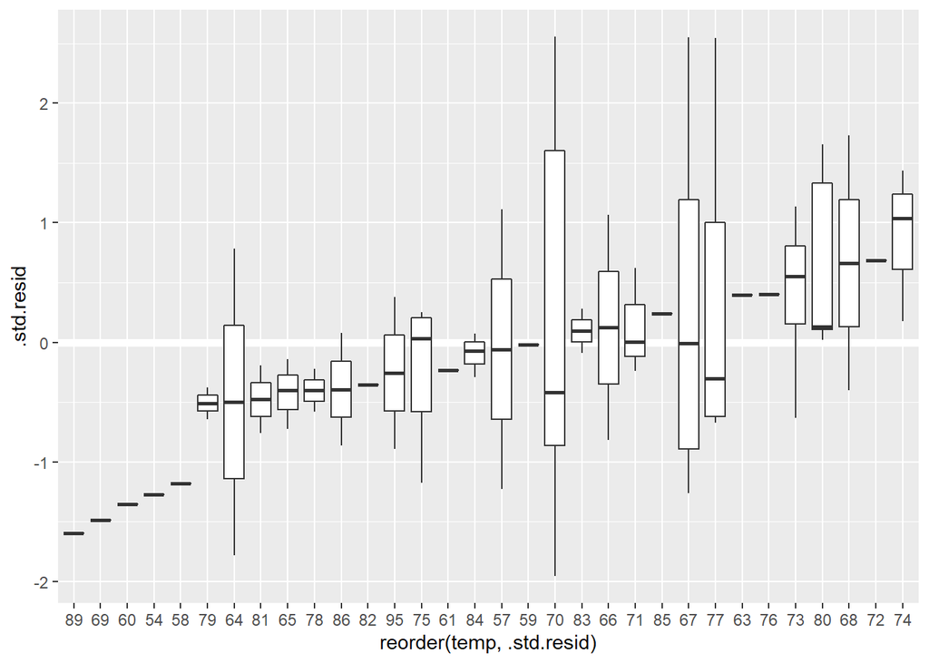

```r
broom::augment(lmod, data=d2) %>%
  mutate(temp = factor(temp)) %>%
  ggplot(aes(reorder(temp, .std.resid), .std.resid)) +
  geom_hline(yintercept=0, col="white", size=2) +
  geom_boxplot()
```

Seemingly on the graph our existing model do not under/overestimate the attendance in certain temperatures, hence, it may not be a strong candidate for our model.

However, we should have F-test to make sure,

```r
lmod
```

```
Call:
lm(formula = attend ~ month + day_of_week + bobblehead, data = d2)

Coefficients:
         (Intercept)              monthMAY              monthJUN
            33909.16              -2385.62               7163.23
            monthJUL              monthAUG              monthSEP
             2849.83               2377.92                 29.03
            monthOCT    day_of_weekTuesday  day_of_weekWednesday
             -662.67               7911.49               2460.02
 day_of_weekThursday     day_of_weekFriday   day_of_weekSaturday
              775.36               4883.82               6372.06
   day_of_weekSunday         bobbleheadYES
             6724.00              10714.90
```

```r
large <- update(lmod, . ~ . + temp)
anova(lmod, large)
```

```
Analysis of Variance Table

Model 1: attend ~ month + day_of_week + bobblehead
Model 2: attend ~ month + day_of_week + bobblehead + temp
  Res.Df        RSS Df Sum of Sq      F Pr(>F)
1     67 2509574563
2     66 2497157624  1  12416939 0.3282 0.5687
```

P-value is so much larger than our significance level, meaning we are not able to reject the small model. Therefore, F-test concluded that temp is unimportant.

Let us check, if we have a mistake in not including and trying other variables such as skies, day_night, cap, shirt and fireworks, which we have teste via chi-squared test that they are not logical candidates for our model.

Introducing ‘skies’ to lmod:

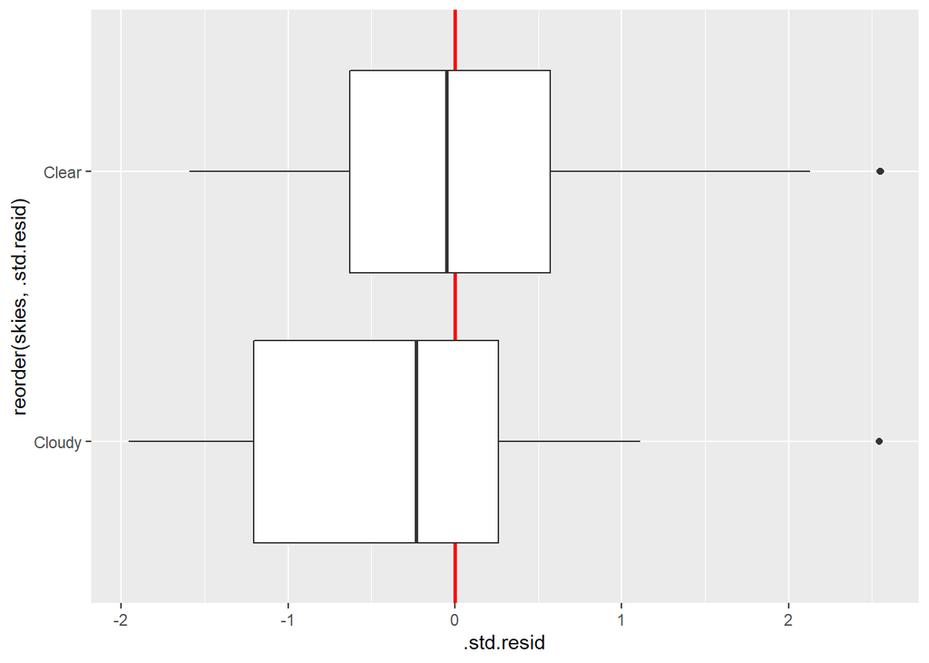

```r
broom::augment(lmod, data=d2) %>%
  mutate(skies = factor(skies)) %>%
  ggplot(aes(reorder(skies, .std.resid), .std.resid)) +
  geom_hline(yintercept=0, col="red", size=1) +
  geom_boxplot() +
  coord_flip()
```

```r
lmod_skies <- lm(attend ~ month + day_of_week + bobblehead + skies, d2)
small <-  update(lmod_skies, . ~ . - skies)
anova(small, lmod_skies)
```

```
Analysis of Variance Table

Model 1: attend ~ month + day_of_week + bobblehead
Model 2: attend ~ month + day_of_week + bobblehead + skies
  Res.Df        RSS Df Sum of Sq      F Pr(>F)
1     67 2509574563
2     66 2430749943  1  78824620 2.1403 0.1482
```

```r
# lmod %>% pander(caption = "Linear regression model")
```

P-value (0.15) is large, so we are not able to reject our small model. Therefore, F-test concluded that skies is unimportant.

Introducing ‘day_night’ to lmod:

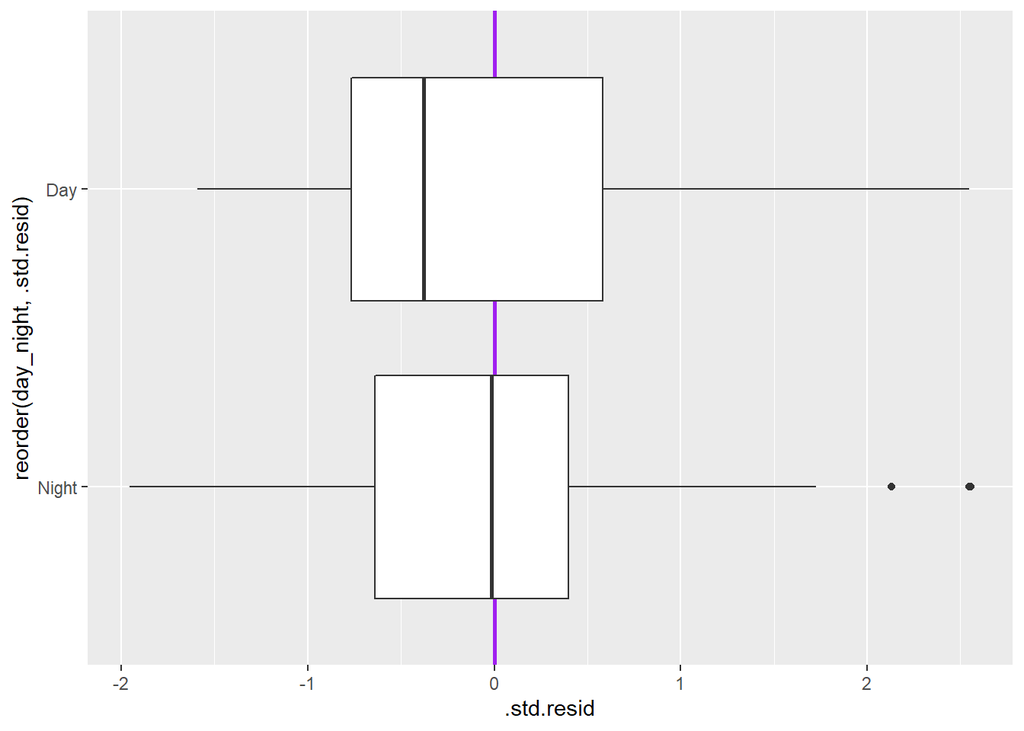

```r
broom::augment(lmod, data=d2) %>%
  mutate(day_night = factor(day_night)) %>%
  ggplot(aes(reorder(day_night, .std.resid), .std.resid)) +
  geom_hline(yintercept=0, col="purple", size=1) +
  geom_boxplot() +
  coord_flip()
```

```r
lmod_dn <- lm(attend ~ month + day_of_week + bobblehead + day_night, d2)

small <-  update(lmod_dn, . ~ . - day_night)
anova(small, lmod_dn)
```

```
Analysis of Variance Table

Model 1: attend ~ month + day_of_week + bobblehead
Model 2: attend ~ month + day_of_week + bobblehead + day_night
  Res.Df        RSS Df Sum of Sq      F Pr(>F)
1     67 2509574563
2     66 2508075740  1   1498824 0.0394 0.8432
```

P-value of this test (0.84) is too bigger than our significance level (0.05), hence we cannot reject our small model. Meaning that we are not able to add ‘day_night’ as a predictor to our regression model.

Introducing ‘cap’ to lmod:

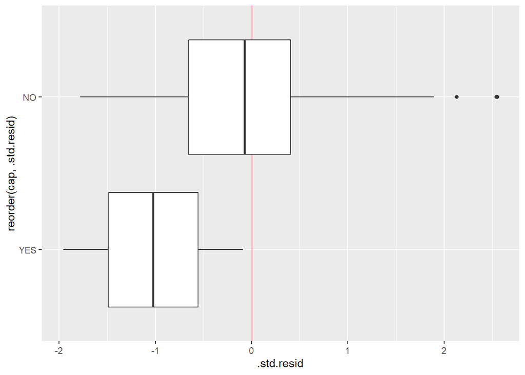

```r
broom::augment(lmod, data=d2) %>%
  mutate(cap = factor(cap)) %>%
  ggplot(aes(reorder(cap, .std.resid), .std.resid)) +
  geom_hline(yintercept=0, col="pink", size=1) +
  geom_boxplot() +
  coord_flip()
```

Provided that our data is enough to observe the distribution of caps, we would also be analyzing the model with the interaction of the variables skies and cap, because people may enjoy the distribution of caps during the games in sunny days. Such as:

```r
lmod
```

```
##
## Call:
## lm(formula = attend ~ month + day_of_week + bobblehead, data = d2)
##
## Coefficients:
##          (Intercept)              monthMAY              monthJUN
##             33909.16              -2385.62               7163.23
##             monthJUL              monthAUG              monthSEP
##              2849.83               2377.92                 29.03
##             monthOCT    day_of_weekTuesday  day_of_weekWednesday
##              -662.67               7911.49               2460.02
##  day_of_weekThursday     day_of_weekFriday   day_of_weekSaturday
##               775.36               4883.82               6372.06
##    day_of_weekSunday         bobbleheadYES
##              6724.00              10714.90
```

```r
lmod_skies_caps <- update(lmod, . ~ . + skies + cap)
anova(lmod, lmod_skies_caps)
```

```
## Analysis of Variance Table
##
## Model 1: attend ~ month + day_of_week + bobblehead
## Model 2: attend ~ month + day_of_week + bobblehead + skies + cap
##   Res.Df        RSS Df Sum of Sq      F Pr(>F)
## 1     67 2509574563
## 2     65 2377604898  2 131969665 1.8039 0.1728
```

As it is explained buy our p-value, the beginning model is much better than the large model, however, let’s assume that our data is sufficient to be explained by the large model and hence our p-value is smaller than our significance level(0.05). Let us continue to observe in a manner that our large model is sufficient.

As a matter of fact, we think that distribution of caps have an affect on increasing the # of attendants in sunny days. Hence, we are expecting an interaction between the predictors cap and skies. Let us test it.

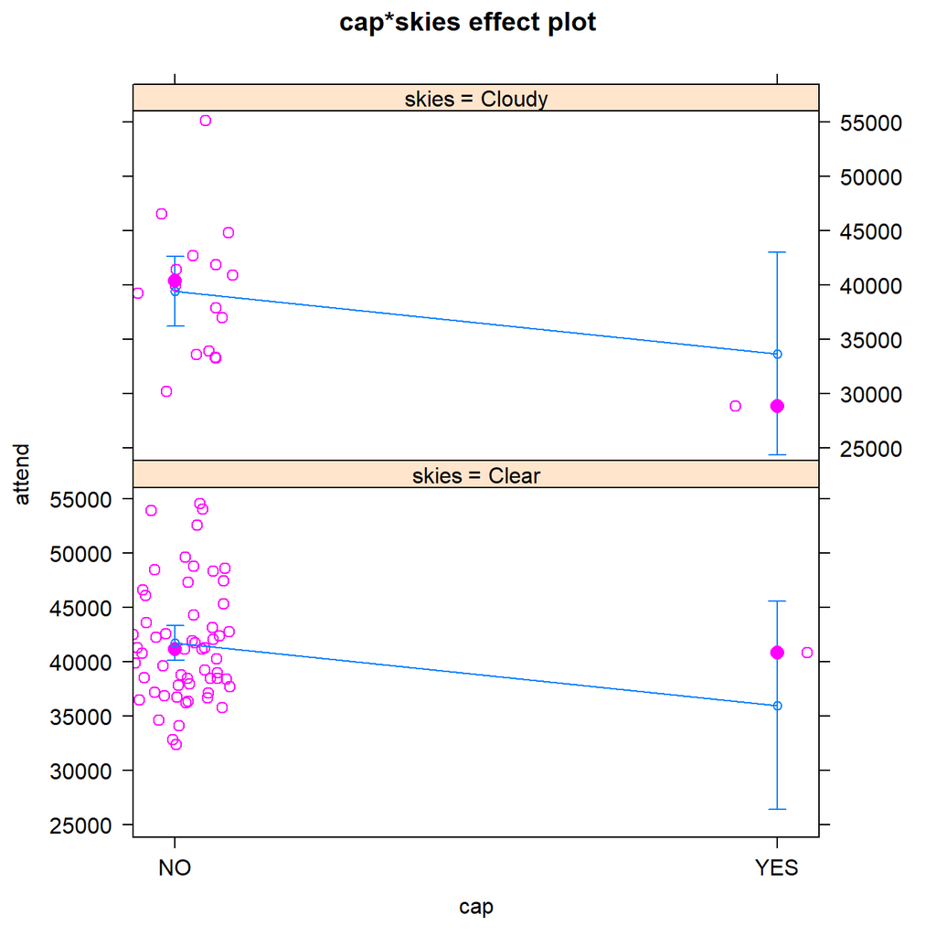

```r
d4 <- mutate(d2, bobblehead = factor(bobblehead))
lmod_skies_caps <- update(lmod_skies_caps, data  = d4)

effects::effect(c("cap","skies"), lmod_skies_caps,
                partial.residuals = TRUE ) %>% plot(layout = c(1,2))
```

Our model seems to overestimate and underestimate effects of cap in different meteorological circumstances. Let us augment model with interaction term and run an F-test to check if it is statistically significant.

### Model selection with F-test

```r
lmod_skies_caps
```

```
Call:
lm(formula = attend ~ month + day_of_week + bobblehead + skies +
    cap, data = d4)

Coefficients:
         (Intercept)              monthMAY              monthJUN
             34846.6               -3405.2                6228.4
            monthJUL              monthAUG              monthSEP
              2903.8                1706.6                -724.9
            monthOCT    day_of_weekTuesday  day_of_weekWednesday
             -1380.5                9003.3                3010.8
 day_of_weekThursday     day_of_weekFriday   day_of_weekSaturday
              1293.0                5123.4                6917.6
   day_of_weekSunday         bobbleheadYES           skiesCloudy
              6866.1                9917.9               -2301.3
              capYES
             -5746.3
```

```r
large <- update(lmod_skies_caps, . ~ . + cap:skies)
anova(lmod_skies_caps, large)
```

```
Analysis of Variance Table

Model 1: attend ~ month + day_of_week + bobblehead + skies + cap
Model 2: attend ~ month + day_of_week + bobblehead + skies + cap + skies:cap
  Res.Df        RSS Df Sum of Sq      F Pr(>F)
1     65 2377604898
2     64 2321551588  1  56053309 1.5453 0.2184
```

### Model selection with AIC

```r
final <- update(lmod_skies_caps, . ~ .^2) %>%  step()
```

```
Start:  AIC=1392.67
attend ~ month + day_of_week + bobblehead + skies + cap + month:day_of_week +
    month:bobblehead + month:skies + month:cap + day_of_week:bobblehead +
    day_of_week:skies + day_of_week:cap + bobblehead:skies +
    bobblehead:cap + skies:cap


Step:  AIC=1392.67
attend ~ month + day_of_week + bobblehead + skies + cap + month:day_of_week +
    month:bobblehead + month:skies + month:cap + day_of_week:bobblehead +
    day_of_week:skies + day_of_week:cap + bobblehead:skies +
    bobblehead:cap


Step:  AIC=1392.67
attend ~ month + day_of_week + bobblehead + skies + cap + month:day_of_week +
    month:bobblehead + month:skies + month:cap + day_of_week:bobblehead +
    day_of_week:skies + day_of_week:cap + bobblehead:skies


Step:  AIC=1392.67
attend ~ month + day_of_week + bobblehead + skies + cap + month:day_of_week +
    month:bobblehead + month:skies + month:cap + day_of_week:bobblehead +
    day_of_week:skies + day_of_week:cap


Step:  AIC=1392.67
attend ~ month + day_of_week + bobblehead + skies + cap + month:day_of_week +
    month:bobblehead + month:skies + month:cap + day_of_week:bobblehead +
    day_of_week:skies


Step:  AIC=1392.67
attend ~ month + day_of_week + bobblehead + skies + cap + month:day_of_week +
    month:bobblehead + month:skies + month:cap + day_of_week:skies

                    Df  Sum of Sq        RSS    AIC
- day_of_week:skies  3    2872956  584009611 1387.1
- month:cap          1    2524611  583661265 1391.0
- month:skies        4   51173287  632309942 1391.5
```

[output cut: 20 more lines]

```
- cap                1    2726928  592837064 1384.3
<none>                             590110135 1385.9
- month:bobblehead   2  121067663  711177798 1397.0
- month:skies        4  273139433  863249569 1408.7
- month:day_of_week 27 1315889331 1905999467 1426.9

Step:  AIC=1384.28
attend ~ month + day_of_week + bobblehead + skies + month:day_of_week +
    month:bobblehead + month:skies

                    Df  Sum of Sq        RSS    AIC
<none>                             592837064 1384.3
- month:bobblehead   2  128063502  720900566 1396.1
- month:skies        4  305615119  898452183 1410.0
- month:day_of_week 27 1344489418 1937326482 1426.2
```

As we see in our newly constructed model, only the interactions between month:day_of_week, month:bobblehead and month:skies may have an importance for our new model. However, cap has got nothing to do with our existing data.

Let’s introduce ‘shirt’ as a new variable to our model:

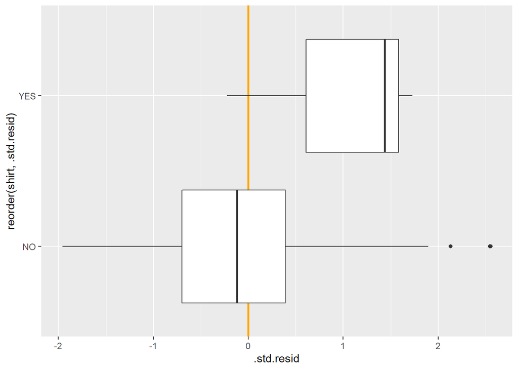

```r
broom::augment(lmod, data=d2) %>%
  mutate(shirt = factor(shirt)) %>%
  ggplot(aes(reorder(shirt, .std.resid), .std.resid)) +
  geom_hline(yintercept=0, col="orange", size=1) +
  geom_boxplot() +
  coord_flip()
```

We seem to underestimate the # of attendants played in different circumstances regarding distribution of shirts, thus, we should investigate if adding this variable in our model is a rational idea.

```r
lmod_shirt <- lm(attend ~ month + day_of_week + bobblehead + shirt, d2)
small <-  update(lmod_shirt, . ~ . - shirt)
anova(small, lmod_shirt)
```

```
Analysis of Variance Table

Model 1: attend ~ month + day_of_week + bobblehead
Model 2: attend ~ month + day_of_week + bobblehead + shirt
  Res.Df        RSS Df Sum of Sq      F  Pr(>F)
1     67 2509574563
2     66 2402756980  1 106817583 2.9341 0.09142 .
---
Signif. codes:  0 '***' 0.001 '**' 0.01 '*' 0.05 '.' 0.1 ' ' 1
```

```r
# lmod %>% pander(caption = "Linear regression model")
```

Although the p-value is larger than our significance level (.05), 0.09 is a considerable number to further investigate. Hence, we might conduct further tests. However, as we examined the variable ‘shirt’ with the chi-squared test, we saw that the data is not enough to observe the affects of the distribution of shirts during games, since our data experienced this incident only 3 times. However, we can conduct F-test with drop1:

```r
drop1(lmod_shirt, test="F")
```

```
Single term deletions

Model:
attend ~ month + day_of_week + bobblehead + shirt
            Df Sum of Sq        RSS    AIC F value     Pr(>F)
<none>                   2402756980 1423.6
month        6 553151673 2955908653 1428.4  2.5324    0.02878 *
day_of_week  6 571326029 2974083009 1428.9  2.6156    0.02458 *
bobblehead   1 784890946 3187647927 1444.5 21.5597 0.00001683 ***
shirt        1 106817583 2509574563 1425.2  2.9341    0.09142 .
---
Signif. codes:  0 '***' 0.001 '**' 0.01 '*' 0.05 '.' 0.1 ' ' 1
```

Hence, it seems that the most useless variable in this model is shirt and all other predictors in the model are necessary to explain our data.

Until now we made sure of almost all variables other than fireworks. For both a double check and ease, let us consider all of the variables together and decide whether fireworks is a nice candidate.

```r
lmod_large <- lm(attend ~ month + day_of_week + bobblehead + opponent + temp + shirt + cap + skies + day_night + fireworks,  d2)
summary(lmod_large)
```

```
Call:
lm(formula = attend ~ month + day_of_week + bobblehead + opponent +
    temp + shirt + cap + skies + day_night + fireworks, data = d2)

Residuals:
    Min      1Q  Median      3Q     Max
-9768.1 -2985.5  -134.4  1524.5 13198.9

Coefficients:
                      Estimate Std. Error t value Pr(>|t|)
(Intercept)           43654.70   17824.74   2.449  0.01828 *
monthMAY               2743.61    5943.16   0.462  0.64656
monthJUN               1712.18   10810.57   0.158  0.87487
monthJUL               4567.79    6208.83   0.736  0.46573
monthAUG               7073.40    7644.85   0.925  0.35977
monthSEP               2301.95    7626.01   0.302  0.76415
monthOCT               2433.82    9039.12   0.269  0.78896
day_of_weekTuesday     8601.50    2939.55   2.926  0.00536 **
day_of_weekWednesday    -32.94    2761.75  -0.012  0.99054
day_of_weekThursday    1011.06    3868.43   0.261  0.79501
day_of_weekFriday    -17886.61    9197.76  -1.945  0.05808 .
day_of_weekSaturday    4285.08    3277.43   1.307  0.19770
day_of_weekSunday      2061.56    4634.49   0.445  0.65857
bobbleheadYES          9717.77    3170.78   3.065  0.00367 **
opponentAstros       -12932.67   11459.67  -1.129  0.26507
opponentBraves       -12213.43   11721.79  -1.042  0.30300
opponentBrewers      -13647.42   11637.58  -1.173  0.24709
opponentCardinals     -6344.35   11113.93  -0.571  0.57094
opponentCubs          -6356.43   11716.41  -0.543  0.59013
opponentGiants       -10257.14   10978.03  -0.934  0.35512
opponentMarlins      -11924.36   11468.97  -1.040  0.30403
opponentMets          -2467.24    6048.28  -0.408  0.68526
opponentNationals        60.94   12053.33   0.005  0.99599
opponentPadres        -6681.52   10109.42  -0.661  0.51203
opponentPhillies      -8082.70   10969.85  -0.737  0.46506
opponentPirates       -7683.96   12162.26  -0.632  0.53072
opponentReds         -13019.93   11264.89  -1.156  0.25386
opponentRockies      -10679.90   10858.93  -0.984  0.33061
opponentSnakes       -13656.81   10628.28  -1.285  0.20538
opponentWhite Sox      -795.82    5724.91  -0.139  0.89006
temp                     11.69     245.63   0.048  0.96226
shirtYES               1481.11    4564.98   0.324  0.74710
capYES                -6432.75    5865.47  -1.097  0.27860
skiesCloudy             271.17    2350.54   0.115  0.90867
day_nightNight        -3052.14    3544.27  -0.861  0.39372
fireworksYES          20634.40    8331.79   2.477  0.01709 *
---
Signif. codes:  0 '***' 0.001 '**' 0.01 '*' 0.05 '.' 0.1 ' ' 1

Residual standard error: 5972 on 45 degrees of freedom
Multiple R-squared:  0.7086,    Adjusted R-squared:  0.482
F-statistic: 3.127 on 35 and 45 DF,  p-value: 0.000187
```

```r
# lmod %>% pander(caption = "Linear regression model")
```

```r
drop1(lmod_large, test="F")
```

```
Single term deletions

Model:
attend ~ month + day_of_week + bobblehead + opponent + temp +
    shirt + cap + skies + day_night + fireworks
            Df Sum of Sq        RSS    AIC F value   Pr(>F)
<none>                   1604980647 1433.0
month        6 110314576 1715295223 1426.3  0.5155 0.793433
day_of_week  6 607711973 2212692620 1447.0  2.8398 0.019754 *
bobblehead   1 335010459 1939991106 1446.3  9.3929 0.003675 **
opponent    16 478805780 2083786427 1422.1  0.8390 0.637156
temp         1     80748 1605061395 1431.0  0.0023 0.962260
shirt        1   3754537 1608735184 1431.2  0.1053 0.747100
cap          1  42898736 1647879383 1433.1  1.2028 0.278601
skies        1    474672 1605455319 1431.0  0.0133 0.908670
day_night    1  26449304 1631429952 1432.3  0.7416 0.393721
fireworks    1 218758090 1823738737 1441.3  6.1335 0.017090 *
---
Signif. codes:  0 '***' 0.001 '**' 0.01 '*' 0.05 '.' 0.1 ' ' 1
```

As we can see in the F test all variables other than day_of_week, bobblehead and fireworks are unimportant for our model. However, in our previous investigations, we observed that month is an important predictor, too. Hence, let us consider a new model:

```r
lmod_new <- lm(attend ~ month + day_of_week + bobblehead + fireworks , d2)
summary(lmod_new)
```

```
Call:
lm(formula = attend ~ month + day_of_week + bobblehead + fireworks,
    data = d2)

Residuals:
   Min     1Q Median     3Q    Max
 -9504  -3683   -709   2569  15390

Coefficients:
                      Estimate Std. Error t value             Pr(>|t|)
(Intercept)           34321.68    2418.90  14.189 < 0.0000000000000002 ***
monthMAY              -2492.79    2193.60  -1.136              0.25990
monthJUN               7062.62    2616.13   2.700              0.00881 **
monthJUL               1315.38    2534.42   0.519              0.60549
monthAUG               2377.88    2300.15   1.034              0.30501
monthSEP                -55.37    2413.63  -0.023              0.98177
monthOCT               -502.88    3873.86  -0.130              0.89711
day_of_weekTuesday     7750.46    2587.35   2.996              0.00386 **
day_of_weekWednesday    904.16    2476.14   0.365              0.71617
day_of_weekThursday     309.24    3341.63   0.093              0.92655
day_of_weekFriday    -12386.23    6901.86  -1.795              0.07729 .
day_of_weekSaturday    6094.17    2445.16   2.492              0.01521 *
day_of_weekSunday      6577.96    2400.14   2.741              0.00788 **
bobbleheadYES         10995.05    2318.43   4.742            0.0000117 ***
fireworksYES          17028.78    6381.63   2.668              0.00958 **
---
Signif. codes:  0 '***' 0.001 '**' 0.01 '*' 0.05 '.' 0.1 ' ' 1

Residual standard error: 5858 on 66 degrees of freedom
Multiple R-squared:  0.5887,    Adjusted R-squared:  0.5015
F-statistic: 6.749 on 14 and 66 DF,  p-value: 0.00000002848
```

```r
# lmod %>% pander(caption = "Linear regression model")
```

###Model selection with AIC

```r
 final <- update(lmod_new, . ~ .^2) %>%  step()
```

```
Start:  AIC=1417.04
attend ~ month + day_of_week + bobblehead + fireworks + month:day_of_week +
    month:bobblehead + month:fireworks + day_of_week:bobblehead +
    day_of_week:fireworks + bobblehead:fireworks


Step:  AIC=1417.04
attend ~ month + day_of_week + bobblehead + fireworks + month:day_of_week +
    month:bobblehead + month:fireworks + day_of_week:bobblehead +
    day_of_week:fireworks


Step:  AIC=1417.04
attend ~ month + day_of_week + bobblehead + fireworks + month:day_of_week +
    month:bobblehead + month:fireworks + day_of_week:bobblehead


Step:  AIC=1417.04
attend ~ month + day_of_week + bobblehead + fireworks + month:day_of_week +
    month:bobblehead + day_of_week:bobblehead

                         Df  Sum of Sq        RSS    AIC
- day_of_week:bobblehead  1   12082574  968730594 1416.1
- month:bobblehead        1   17121963  973769983 1416.5
<none>                                  956648020 1417.0
- fireworks               1   92684112 1049332132 1422.5
- month:day_of_week      27 1175471727 2132119747 1428.0

Step:  AIC=1416.06
attend ~ month + day_of_week + bobblehead + fireworks + month:day_of_week +
    month:bobblehead

                    Df  Sum of Sq        RSS    AIC
- month:bobblehead   2   21481210  990211803 1413.8
<none>                             968730594 1416.1
- fireworks          1   92684112 1061414706 1421.5
- month:day_of_week 29 1210278919 2179009513 1423.7

Step:  AIC=1413.84
attend ~ month + day_of_week + bobblehead + fireworks + month:day_of_week

                    Df  Sum of Sq        RSS    AIC
<none>                             990211803 1413.8
- month:day_of_week 31 1274982975 2265194779 1418.9
- fireworks          1   92684112 1082895916 1419.1
- bobblehead         1  351400539 1341612342 1436.4
```

Hence the interaction between month:day_of_week seems to be useful for our model

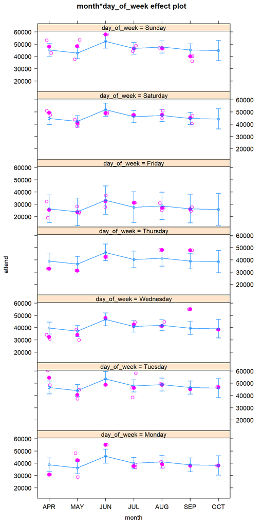

```r
d3 <- mutate(d2, bobblehead = factor(bobblehead))
lmod_new <- update(lmod_new, data  = d3)

effects::effect(c("month","day_of_week"), lmod_new,
                partial.residuals = TRUE ) %>% plot(layout = c(1,7))
```

Hence, the interaction between month and day_of_week seems to be valuable to observe the effects on our data. So, let us check if it is significant via F-test.

```r
lmod_new
```

```
Call:
lm(formula = attend ~ month + day_of_week + bobblehead + fireworks,
    data = d3)

Coefficients:
         (Intercept)              monthMAY              monthJUN
            34321.68              -2492.79               7062.62
            monthJUL              monthAUG              monthSEP
             1315.38               2377.88                -55.37
            monthOCT    day_of_weekTuesday  day_of_weekWednesday
             -502.88               7750.46                904.16
 day_of_weekThursday     day_of_weekFriday   day_of_weekSaturday
              309.24             -12386.23               6094.17
   day_of_weekSunday         bobbleheadYES          fireworksYES
             6577.96              10995.05              17028.78
```

```r
large <- update(lmod_new, . ~ . + month:day_of_week)
anova(lmod_new, large)
```

```
Analysis of Variance Table

Model 1: attend ~ month + day_of_week + bobblehead + fireworks
Model 2: attend ~ month + day_of_week + bobblehead + fireworks + month:day_of_week
  Res.Df        RSS Df  Sum of Sq      F Pr(>F)
1     66 2265194779
2     35  990211803 31 1274982975 1.4537 0.1417
```

P-value is large, hence we cannot reject our previous model.

### Model selection with cross-validation and t-test

Checking whether the fireworks term is necessary with **cross-validation**

```r
set.seed(460)
nfolds <- 5
folds <- rep(seq(5), nrow(d2), len=nrow(d2)) %>% sample()
rmse_lmod <- rep(NA, nfolds)
rmse_lmod_fireworks <- rep(NA, nfolds)


for (i in seq(nfolds)){
  train <- d2[folds!=i,]
  test <- d2[folds==i,]

  lmod_fireworks <- lm(attend ~ month + day_of_week + bobblehead + fireworks , d2)

  # train lm without fireworks
  lmod_train <- update(lmod, data = train)
  lmod_test <- predict(lmod_train, newdata = test)
  rmse_lmod[i] <- (test$attend - lmod_test)^2 %>% mean() %>% sqrt()

  # train lm with fireworks model
  lmod_fireworks_train <- update(lmod_fireworks, data = train)
  lmod_fireworks_test <- suppressWarnings(predict(lmod_fireworks_train, newdata = test))
  rmse_lmod_fireworks[i] <- (test$attend - lmod_fireworks_test)^2 %>% mean() %>% sqrt()
}

cv <- tibble(lmod = rmse_lmod, lmod_fireworks = rmse_lmod_fireworks) %>%
  mutate(dif_rmse = lmod - lmod_fireworks)

cv %>%
  apply(2,mean)
```

```
          lmod lmod_fireworks       dif_rmse
    6380.98534     6407.45280      -26.46747
```

```r
t.test(x = cv$dif_rmse)
```

```
    One Sample t-test

data:  cv$dif_rmse
t = -0.39203, df = 4, p-value = 0.715
alternative hypothesis: true mean is not equal to 0
95 percent confidence interval:
 -213.9142  160.9793
sample estimates:
mean of x
-26.46747
```

```r
#p1 <- cv %>%
  #pivot_longer(cols=c(lmod_new, lmod_interaction), names_to = "model", values_to = "rmse") %>%
  #ggplot(aes(model, rmse)) +
  #geom_boxplot(aes(fill=model)) +
  #theme(legend.position = "none")
```

```r
drop1(lmod_fireworks, test="F")
```

```
## Single term deletions
##
## Model:
## attend ~ month + day_of_week + bobblehead + fireworks
##             Df Sum of Sq        RSS    AIC F value    Pr(>F)
## <none>                   2265194779 1418.9
## month        6 585783623 2850978402 1425.5  2.8446  0.015904 *
## day_of_week  6 782480902 3047675681 1430.9  3.7998  0.002597 **
## bobblehead   1 771915869 3037110648 1440.6 22.4910 0.0000117 ***
## fireworks    1 244379784 2509574563 1425.2  7.1204  0.009581 **
## ---
## Signif. codes:  0 '***' 0.001 '**' 0.01 '*' 0.05 '.' 0.1 ' ' 1
```

```r
confint(lmod_fireworks, level = 0.80)["bobbleheadYES",]
```

```
##      10 %      90 %
##  7993.827 13996.279
```

```r
confint(lmod_fireworks, level = 0.80)["fireworksYES",]
```

```
##      10 %      90 %
##  8767.691 25289.868
```

**As we conducted an F-test on the importance of terms included currently, we conclude that all (boo) of the predictors are significant for our response variable. We checked the additional possible attendance (confidence level = 80%) due to these variables included.

```r
 final_fireworks <- update(lmod_fireworks, . ~ .^2) %>%  step()
```

```
## Start:  AIC=1417.04
## attend ~ month + day_of_week + bobblehead + fireworks + month:day_of_week +
##     month:bobblehead + month:fireworks + day_of_week:bobblehead +
##     day_of_week:fireworks + bobblehead:fireworks
##
##
## Step:  AIC=1417.04
## attend ~ month + day_of_week + bobblehead + fireworks + month:day_of_week +
##     month:bobblehead + month:fireworks + day_of_week:bobblehead +
##     day_of_week:fireworks
##
##
## Step:  AIC=1417.04
## attend ~ month + day_of_week + bobblehead + fireworks + month:day_of_week +
##     month:bobblehead + month:fireworks + day_of_week:bobblehead
##
##
## Step:  AIC=1417.04
## attend ~ month + day_of_week + bobblehead + fireworks + month:day_of_week +
##     month:bobblehead + day_of_week:bobblehead
##
##                          Df  Sum of Sq        RSS    AIC
## - day_of_week:bobblehead  1   12082574  968730594 1416.1
## - month:bobblehead        1   17121963  973769983 1416.5
## <none>                                  956648020 1417.0
## - fireworks               1   92684112 1049332132 1422.5
## - month:day_of_week      27 1175471727 2132119747 1428.0
##
## Step:  AIC=1416.06
## attend ~ month + day_of_week + bobblehead + fireworks + month:day_of_week +
##     month:bobblehead
##
##                     Df  Sum of Sq        RSS    AIC
## - month:bobblehead   2   21481210  990211803 1413.8
## <none>                             968730594 1416.1
## - fireworks          1   92684112 1061414706 1421.5
## - month:day_of_week 29 1210278919 2179009513 1423.7
##
## Step:  AIC=1413.84
## attend ~ month + day_of_week + bobblehead + fireworks + month:day_of_week
##
##                     Df  Sum of Sq        RSS    AIC
## <none>                             990211803 1413.8
## - month:day_of_week 31 1274982975 2265194779 1418.9
## - fireworks          1   92684112 1082895916 1419.1
## - bobblehead         1  351400539 1341612342 1436.4
```

```r
summary(final_fireworks)
```

```
##
## Call:
## lm(formula = attend ~ month + day_of_week + bobblehead + fireworks +
##     month:day_of_week, data = d2)
##
## Residuals:
##    Min     1Q Median     3Q    Max
## -11035  -1517      0   1686  10851
##
## Coefficients: (5 not defined because of singularities)
##                               Estimate Std. Error t value  Pr(>|t|)
## (Intercept)                      26376       5319   4.959 0.0000182 ***
## monthMAY                          8971       6142   1.461  0.153035
## monthJUN                         24183       7522   3.215  0.002805 **
## monthJUL                          6928       6142   1.128  0.267017
## monthAUG                          8392       6514   1.288  0.206095
## monthSEP                          7164       7522   0.952  0.347435
## monthOCT                          7248       7522   0.964  0.341883
## day_of_weekTuesday               23631       6514   3.627  0.000903 ***
## day_of_weekWednesday              1661       6514   0.255  0.800236
## day_of_weekThursday               1952       7522   0.259  0.796771
## day_of_weekFriday                -1787       9951  -0.180  0.858517
## day_of_weekSaturday              17884       6743   2.652  0.011939 *
## day_of_weekSunday                17180       6514   2.637  0.012384 *
## bobbleheadYES                    12272       3482   3.524  0.001205 **
## fireworksYES                     13615       7522   1.810  0.078893 .
## monthMAY:day_of_weekTuesday     -23488       8166  -2.876  0.006809 **
## monthJUN:day_of_weekTuesday     -31183      10543  -2.958  0.005521 **
## monthJUL:day_of_weekTuesday     -14287       7915  -1.805  0.079667 .
## monthAUG:day_of_weekTuesday     -15159       9102  -1.665  0.104756
## monthSEP:day_of_weekTuesday     -16552       9951  -1.663  0.105171
## monthOCT:day_of_weekTuesday     -14782       9951  -1.485  0.146367
## monthMAY:day_of_weekWednesday    -7257       8125  -0.893  0.377862
## monthJUN:day_of_weekWednesday    -8726       9951  -0.877  0.386519
## monthJUL:day_of_weekWednesday     4990       8953   0.557  0.580816
## monthAUG:day_of_weekWednesday     1522       8125   0.187  0.852535
## monthSEP:day_of_weekWednesday    15359       9951   1.543  0.131711
## monthOCT:day_of_weekWednesday    -1271       9951  -0.128  0.899096
## monthMAY:day_of_weekThursday    -10526       9711  -1.084  0.285814
## monthJUN:day_of_weekThursday    -15777      11193  -1.409  0.167516
```

[output cut: 13 more lines]

```
## monthAUG:day_of_weekSaturday     -9216       8588  -1.073  0.290579
## monthSEP:day_of_weekSaturday    -11702       9121  -1.283  0.207934
## monthOCT:day_of_weekSaturday        NA         NA      NA        NA
## monthMAY:day_of_weekSunday      -10382       7829  -1.326  0.193417
## monthJUN:day_of_weekSunday      -14235       9951  -1.431  0.161436
## monthJUL:day_of_weekSunday       -9083       8309  -1.093  0.281834
## monthAUG:day_of_weekSunday       -9748       8410  -1.159  0.254292
## monthSEP:day_of_weekSunday      -16397       8953  -1.831  0.075557 .
## monthOCT:day_of_weekSunday          NA         NA      NA        NA
## ---
## Signif. codes:  0 '***' 0.001 '**' 0.01 '*' 0.05 '.' 0.1 ' ' 1
##
## Residual standard error: 5319 on 35 degrees of freedom
## Multiple R-squared:  0.8202, Adjusted R-squared:  0.5891
## F-statistic: 3.549 on 45 and 35 DF,  p-value: 0.00009719
```

```r
anova(lmod_fireworks, final_fireworks)
```

```
## Analysis of Variance Table
##
## Model 1: attend ~ month + day_of_week + bobblehead + fireworks
## Model 2: attend ~ month + day_of_week + bobblehead + fireworks + month:day_of_week
##   Res.Df        RSS Df  Sum of Sq      F Pr(>F)
## 1     66 2265194779
## 2     35  990211803 31 1274982975 1.4537 0.1417
```

**The interaction term between month and day_of_week seems significant regarding to the AIC measures.

```r
set.seed(460)

nfolds <- 5
folds <- rep(seq(5), nrow(d2), len=nrow(d2)) %>% sample()
rmse_lmod_fireworks <- rep(NA, nfolds)
rmse_lmod_interaction <- rep(NA, nfolds)

lmod_interaction <- update(lmod_fireworks, . ~ . + month:day_of_week)

for (i in seq(nfolds)){
  train <- d2[folds!=i,]
  test <- d2[folds==i,]

  # train lm without interaction model
  lmod_train <- update(lmod_fireworks, data = train)
  lmod_test <- predict(lmod_train, newdata = test)
  rmse_lmod[i] <- (test$attend - lmod_test)^2 %>% mean() %>% sqrt()

  # train lm with interaction model
  lmod_interaction_train <- update(lmod_interaction, data = train)
  lmod_interaction_test <- suppressWarnings(predict(lmod_interaction_train, newdata = test))
  rmse_lmod_interaction[i] <- (test$attend - lmod_interaction_test)^2 %>% mean() %>% sqrt()
}
cv <- tibble(lmod = rmse_lmod, lmod_interaction = rmse_lmod_interaction) %>%
  mutate(dif_rmse = lmod - lmod_interaction)

cv %>%
  apply(2,mean)
```

```
##             lmod lmod_interaction         dif_rmse
##         6407.453         9836.378        -3428.925
```

```r
t.test(x = cv$dif_rmse)
```

```
##
##  One Sample t-test
##
## data:  cv$dif_rmse
## t = -3.3673, df = 4, p-value = 0.02811
## alternative hypothesis: true mean is not equal to 0
## 95 percent confidence interval:
##  -6256.1864  -601.6637
## sample estimates:
## mean of x
## -3428.925
```

** As we observe the statistics provided by the cross-validation method, including interaction term of month:day_of_week is a worse fit than the null model (lmod_fireworks). So, we don’t include it in our model. (p-value < 0.05 and t < 0)

** Since the explanatory variable are only consisting of non-numerical factors, we can not apply any kind of non-linear transformation.